# Case Study

## Introduction

### The Data

```r
data <- read.csv("data/data-train.csv")
data
```

```
##      St  Re    Fr R_moment_1 R_moment_2 R_moment_3 R_moment_4
## 1  0.10 224 0.052 0.00215700 1.3035e-01 1.4374e+01 1.5865e+03
## 2  3.00 224 0.052 0.00379030 4.7042e-01 6.9940e+01 1.0404e+04
## 3  0.70 224   Inf 0.00290540 4.3499e-02 8.2200e-01 1.5551e+01
## 4  0.05  90   Inf 0.06352800 9.0653e-02 4.6746e-01 3.2696e+00
## 5  0.70 398   Inf 0.00036945 6.2242e-03 1.2649e-01 2.5714e+00
## 6  2.00  90 0.300 0.14780000 2.0068e+00 3.6249e+01 6.7167e+02
## 7  0.20  90   Inf 0.08127300 3.2450e-01 3.0363e+00 3.2976e+01
## 8  3.00 224   Inf 0.00574730 1.1966e-01 2.7480e+00 6.3159e+01
## 9  0.90 224   Inf 0.00302150 4.5244e-02 8.4530e-01 1.5809e+01
## 10 0.60 398 0.052 0.00031431 4.4672e-03 8.2060e-02 1.5077e+00
## 11 0.90  90   Inf 0.09102700 5.9539e-01 7.2454e+00 9.5166e+01
## 12 0.30 398   Inf 0.00036022 6.2830e-03 1.3546e-01 2.9211e+00
## 13 2.00 224   Inf 0.00447250 8.0804e-02 1.6668e+00 3.4408e+01
## 14 1.00 224 0.052 0.00312380 3.6478e-01 5.3322e+01 7.7958e+03
```

[output cut: 75 more lines]

### Goals

Prediction: For a new parameter setting of (Re, F r, St), predict its particle cluster volume distribution in terms of its four raw moments.

Inference: Investigate and interpret how each parameter affects the probability distribution for particle cluster volumes

## Exploratory Data Analysis

First, we will explore the data to ensure it is fit for modelling and determine inital transformations needed of the data, and which model we see would best fit the data.

```r
names(data)
```

```
## [1] "St"         "Re"         "Fr"         "R_moment_1" "R_moment_2"
## [6] "R_moment_3" "R_moment_4"
```

```r
summary(data)
```

```
##        St               Re              Fr          R_moment_1
##  Min.   :0.0500   Min.   : 90.0   Min.   :0.052   Min.   :0.000222
##  1st Qu.:0.3000   1st Qu.: 90.0   1st Qu.:0.052   1st Qu.:0.002157
##  Median :0.7000   Median :224.0   Median :0.300   Median :0.002958
##  Mean   :0.8596   Mean   :214.5   Mean   :  Inf   Mean   :0.040394
##  3rd Qu.:1.0000   3rd Qu.:224.0   3rd Qu.:  Inf   3rd Qu.:0.087868
##  Max.   :3.0000   Max.   :398.0   Max.   :  Inf   Max.   :0.172340
##    R_moment_2          R_moment_3        R_moment_4
##  Min.   :   0.0001   Min.   :      0   Min.   :0.000e+00
##  1st Qu.:   0.0245   1st Qu.:      0   1st Qu.:3.000e+00
##  Median :   0.0808   Median :      1   Median :2.100e+01
##  Mean   :  92.4902   Mean   : 753370   Mean   :6.194e+09
##  3rd Qu.:   0.5345   3rd Qu.:     40   3rd Qu.:5.345e+03
##  Max.   :1044.3000   Max.   :9140000   Max.   :8.000e+10
```

### Histograms

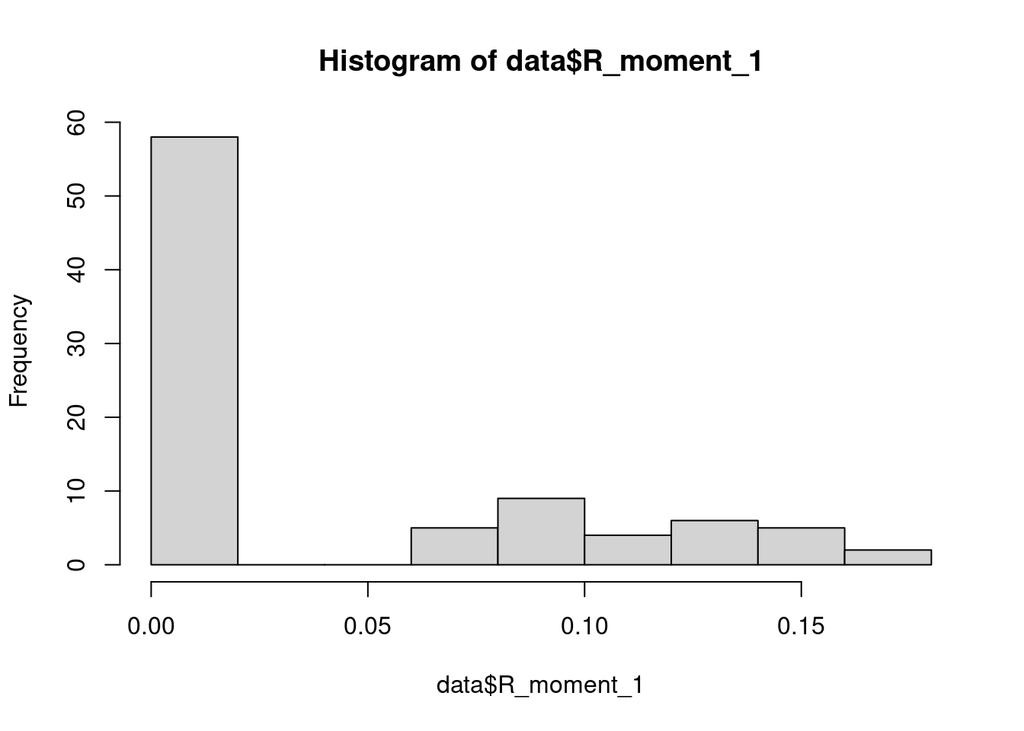

```r
hist(data$R_moment_1)
```

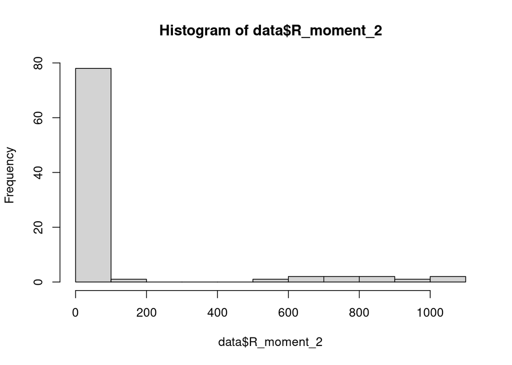

```r
hist(data$R_moment_2)
```

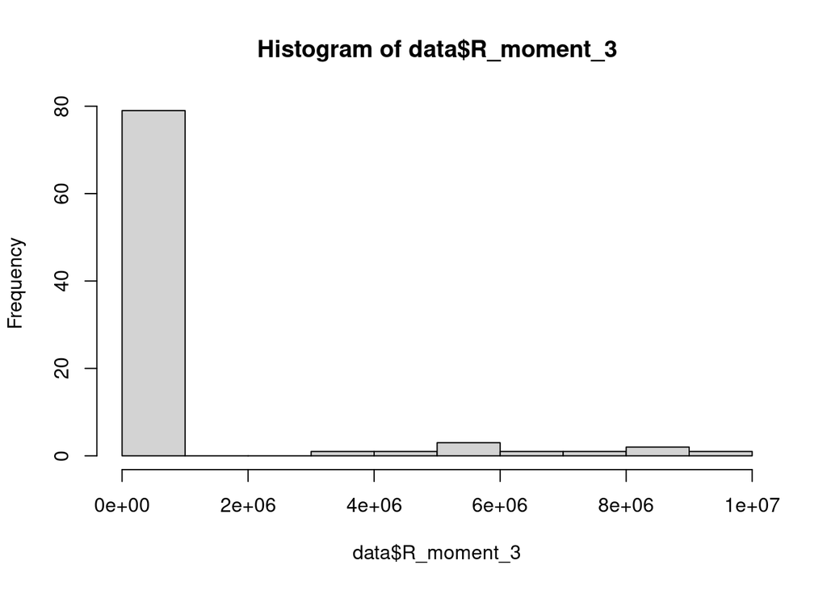

```r
hist(data$R_moment_3)
```

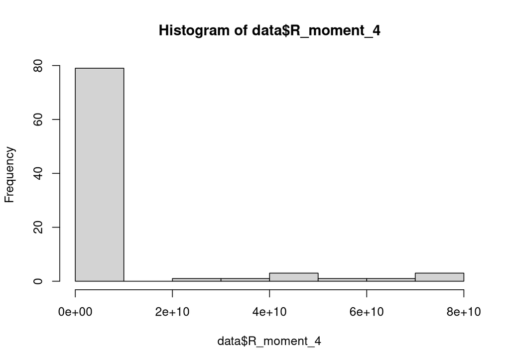

```r
hist(data$R_moment_4)
```

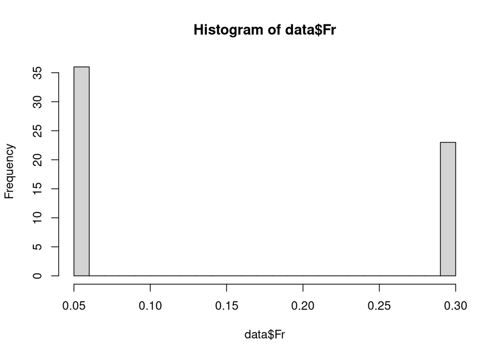

```r
hist(data$Fr, breaks=20)
```

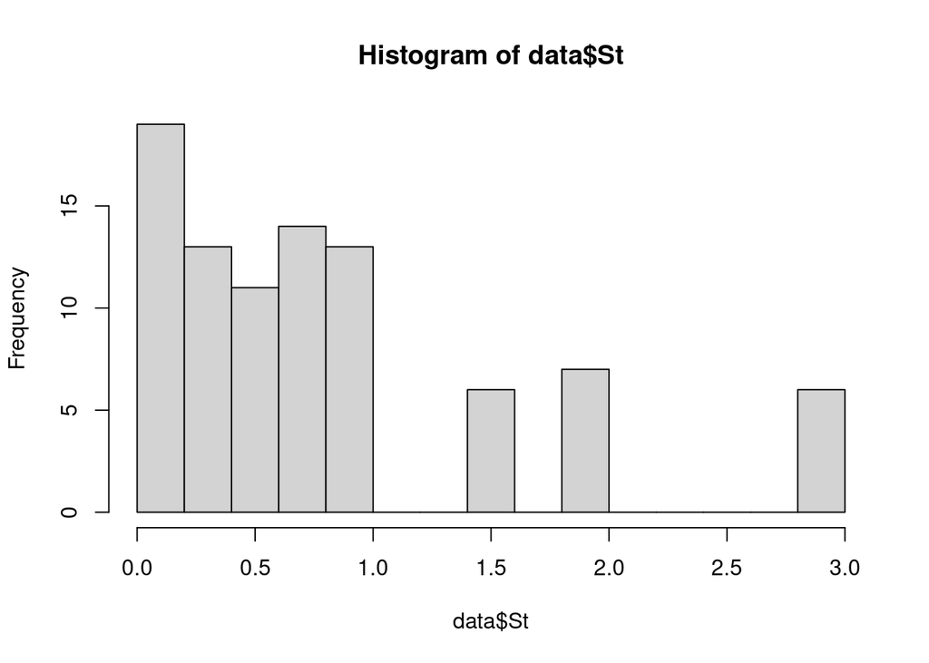

```r
hist(data$St, breaks=20)
```

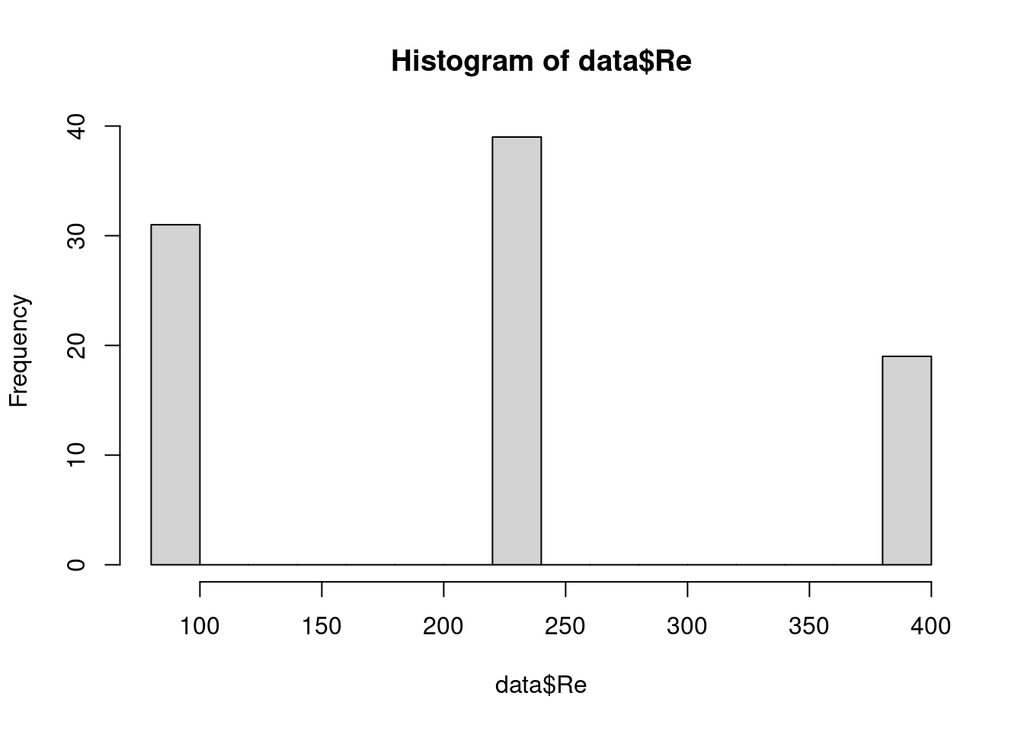

```r
hist(data$Re, breaks=20)
```

With these histograms its clear to see that each R_moment is heavily right skewed, since there are many rows of 0 in the data. In R_moment_3 and R_moment_4, the maximum values are extremely high whereas the medians are much smaller in comparison, which poses a problem to the analysis. We believe it is best then to apply a transformation to these variables in order to obtain more accurate analysis.

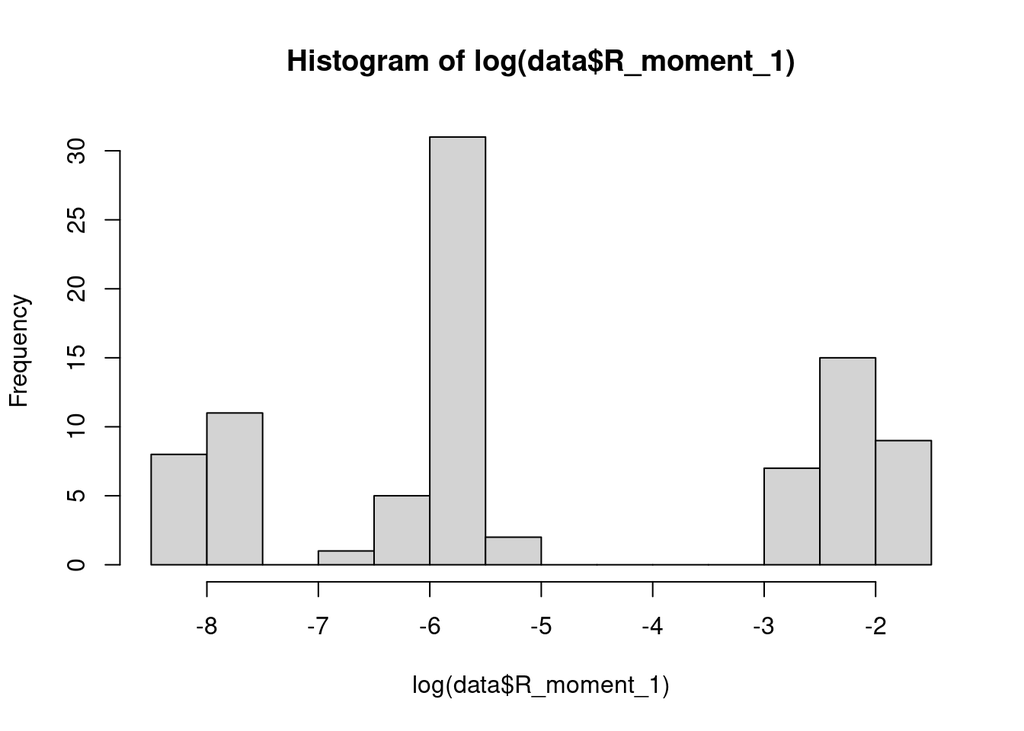

```r
hist(log(data$R_moment_1), breaks=20)
```

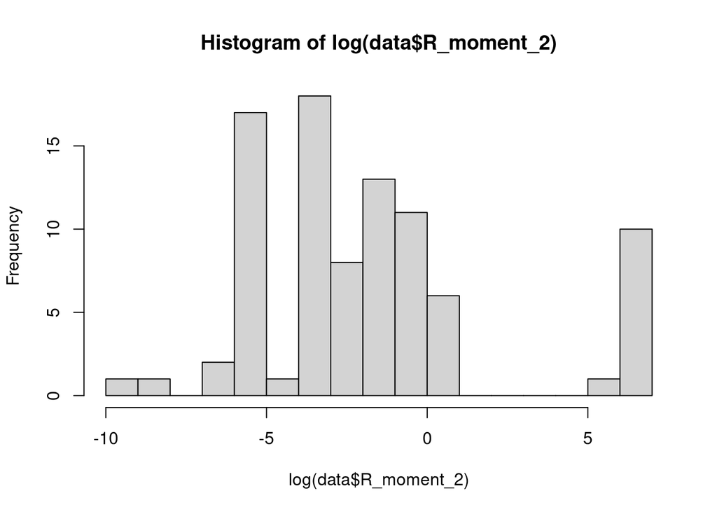

```r
hist(log(data$R_moment_2), breaks=20)
```

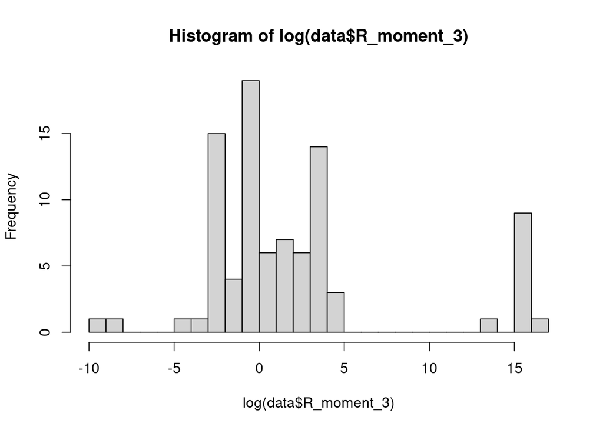

```r
hist(log(data$R_moment_3), breaks=20)
```

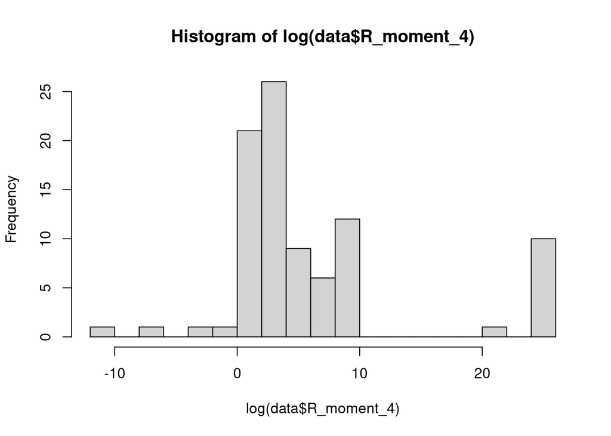

```r
hist(log(data$R_moment_4), breaks=20)
```

Performing a log transformation on these variables created more normally distributed variables. While not perfectly normal, this is a big improvement to the non-transformed variables. From here on out, the log version of variables will be used and will be reflected as such in our interpretations and analysis.

One thing that we should do is turn Fr and Re into ordered, categorical variables, because they only have 2 or 3 unique values each.

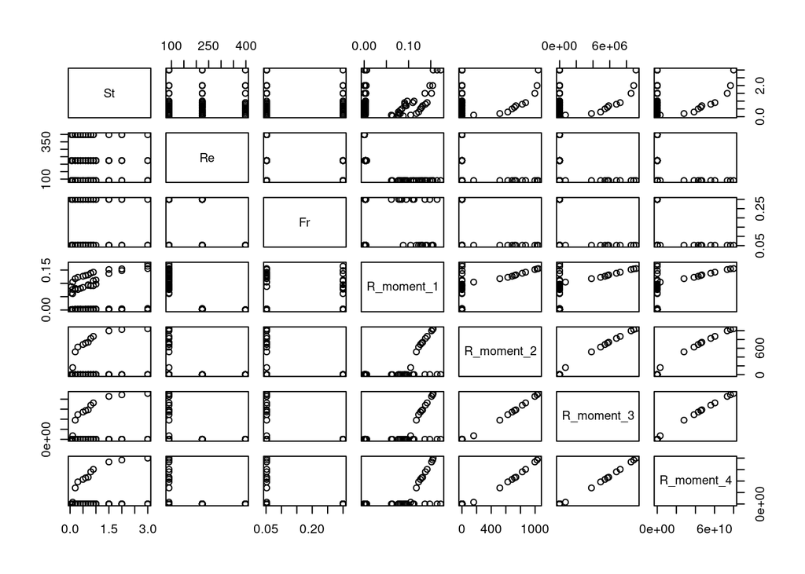

```r
pairs(data)
```

It appears that each R_moment variable has somewhat of a linear relationship with St.

## Initial Modelling

We will fit a basic linear model onto each log-transformed response variable.

```r
model1 <- lm(log(R_moment_1) ~ St + factor(Re) + factor(Fr), data=data)

summary(model1)
```

```
##
## Call:
## lm(formula = log(R_moment_1) ~ St + factor(Re) + factor(Fr),
##     data = data)
##
## Residuals:
##      Min       1Q   Median       3Q      Max
## -0.47532 -0.07168  0.02101  0.10237  0.23554
##
## Coefficients:
##               Estimate Std. Error  t value Pr(>|t|)
## (Intercept)   -2.40825    0.04137  -58.218   <2e-16 ***
## St             0.24652    0.02165   11.386   <2e-16 ***
## factor(Re)224 -3.62590    0.03836  -94.517   <2e-16 ***
## factor(Re)398 -5.75678    0.04826 -119.287   <2e-16 ***
## factor(Fr)0.3 -0.10770    0.04422   -2.435    0.017 *
## factor(Fr)Inf -0.02584    0.03945   -0.655    0.514
## ---
## Signif. codes:  0 '***' 0.001 '**' 0.01 '*' 0.05 '.' 0.1 ' ' 1
##
## Residual standard error: 0.1593 on 83 degrees of freedom
## Multiple R-squared:  0.9952, Adjusted R-squared:  0.9949
## F-statistic:  3460 on 5 and 83 DF,  p-value: < 2.2e-16
```

```r
model2 <- lm(log(R_moment_2) ~ St + factor(Re) + factor(Fr), data=data)

summary(model2)
```

```
##
## Call:
## lm(formula = log(R_moment_2) ~ St + factor(Re) + factor(Fr),
##     data = data)
##
## Residuals:
##     Min      1Q  Median      3Q     Max
## -5.0075 -1.2112 -0.1009  1.1631  3.0215
##
## Coefficients:
##               Estimate Std. Error t value Pr(>|t|)
## (Intercept)     3.2049     0.4690   6.833 1.29e-09 ***
## St              0.7167     0.2455   2.920  0.00451 **
## factor(Re)224  -4.6321     0.4350 -10.650  < 2e-16 ***
## factor(Re)398  -7.7930     0.5472 -14.242  < 2e-16 ***
## factor(Fr)0.3  -3.4422     0.5014  -6.865 1.12e-09 ***
## factor(Fr)Inf  -2.7650     0.4473  -6.182 2.27e-08 ***
## ---
## Signif. codes:  0 '***' 0.001 '**' 0.01 '*' 0.05 '.' 0.1 ' ' 1
##
## Residual standard error: 1.806 on 83 degrees of freedom
## Multiple R-squared:  0.7768, Adjusted R-squared:  0.7633
## F-statistic: 57.76 on 5 and 83 DF,  p-value: < 2.2e-16
```

```r
model3 <- lm(log(R_moment_3) ~ St + factor(Re) + factor(Fr), data=data)

summary(model3)
```

```
##
## Call:
## lm(formula = log(R_moment_3) ~ St + factor(Re) + factor(Fr),
##     data = data)
##
## Residuals:
##     Min      1Q  Median      3Q     Max
## -7.7282 -2.3839 -0.4306  2.1123  5.4634
##
## Coefficients:
##               Estimate Std. Error t value Pr(>|t|)
## (Intercept)     9.6598     0.8341  11.581  < 2e-16 ***
## St              0.9452     0.4366   2.165   0.0332 *
## factor(Re)224  -5.8796     0.7735  -7.601 4.03e-11 ***
## factor(Re)398 -10.2176     0.9731 -10.500  < 2e-16 ***
## factor(Fr)0.3  -6.8055     0.8917  -7.632 3.50e-11 ***
## factor(Fr)Inf  -5.4848     0.7955  -6.895 9.77e-10 ***
## ---
## Signif. codes:  0 '***' 0.001 '**' 0.01 '*' 0.05 '.' 0.1 ' ' 1
##
## Residual standard error: 3.211 on 83 degrees of freedom
## Multiple R-squared:  0.6983, Adjusted R-squared:  0.6802
## F-statistic: 38.43 on 5 and 83 DF,  p-value: < 2.2e-16
```

```r
model4 <- lm(log(R_moment_4) ~ St + factor(Re) + factor(Fr), data=data)

summary(model4)
```

```
##
## Call:
## lm(formula = log(R_moment_4) ~ St + factor(Re) + factor(Fr),
##     data = data)
##
## Residuals:
##      Min       1Q   Median       3Q      Max
## -10.1076  -3.5768  -0.7964   3.0052   7.8067
##
## Coefficients:
##               Estimate Std. Error t value Pr(>|t|)
## (Intercept)    16.2281     1.1836  13.711  < 2e-16 ***
## St              1.1304     0.6195   1.825   0.0716 .
## factor(Re)224  -7.1866     1.0977  -6.547 4.58e-09 ***
## factor(Re)398 -12.7305     1.3808  -9.219 2.38e-14 ***
## factor(Fr)0.3 -10.1437     1.2654  -8.016 6.04e-12 ***
## factor(Fr)Inf  -8.1791     1.1288  -7.246 2.02e-10 ***
## ---
## Signif. codes:  0 '***' 0.001 '**' 0.01 '*' 0.05 '.' 0.1 ' ' 1
##
## Residual standard error: 4.557 on 83 degrees of freedom
## Multiple R-squared:  0.6716, Adjusted R-squared:  0.6518
## F-statistic: 33.95 on 5 and 83 DF,  p-value: < 2.2e-16
```

Exploring collinearity:

```r
vif(model1)
```

```
##                GVIF Df GVIF^(1/(2*Df))
## St         1.004871  1        1.002433
## factor(Re) 1.107716  2        1.025905
## factor(Fr) 1.109374  2        1.026289
```

```r
vif(model2)
```

```
##                GVIF Df GVIF^(1/(2*Df))
## St         1.004871  1        1.002433
## factor(Re) 1.107716  2        1.025905
## factor(Fr) 1.109374  2        1.026289
```

```r
vif(model3)
```

```
##                GVIF Df GVIF^(1/(2*Df))
## St         1.004871  1        1.002433
## factor(Re) 1.107716  2        1.025905
## factor(Fr) 1.109374  2        1.026289
```

```r
vif(model4)
```

```
##                GVIF Df GVIF^(1/(2*Df))
## St         1.004871  1        1.002433
## factor(Re) 1.107716  2        1.025905
## factor(Fr) 1.109374  2        1.026289
```

When all interaction terms are included:

```r
glm.full <- lm(cbind(log(R_moment_1), log(R_moment_2), log(R_moment_3), log(R_moment_4)) ~  (St + factor(Re) + factor(Fr))^2, data=data)
summary(glm.full)
```

```
## Response log(R_moment_1) :
##
## Call:
## lm(formula = `log(R_moment_1)` ~ (St + factor(Re) + factor(Fr))^2,
##     data = data)
##
## Residuals:
##      Min       1Q   Median       3Q      Max
## -0.41510 -0.01331  0.01761  0.05940  0.13973
##
## Coefficients: (1 not defined because of singularities)
##                              Estimate Std. Error t value Pr(>|t|)
## (Intercept)                 -2.186457   0.044127 -49.549  < 2e-16 ***
## St                           0.152307   0.032368   4.705 1.11e-05 ***
## factor(Re)224               -3.854073   0.055437 -69.522  < 2e-16 ***
## factor(Re)398               -5.970943   0.066863 -89.301  < 2e-16 ***
## factor(Fr)0.3               -0.419887   0.065701  -6.391 1.20e-08 ***
## factor(Fr)Inf               -0.454654   0.059741  -7.610 6.11e-11 ***
## St:factor(Re)224             0.041342   0.035969   1.149 0.254002
## St:factor(Re)398            -0.005585   0.046504  -0.120 0.904722
## St:factor(Fr)0.3             0.165845   0.044159   3.756 0.000337 ***
## St:factor(Fr)Inf             0.146870   0.037025   3.967 0.000164 ***
## factor(Re)224:factor(Fr)0.3  0.252705   0.067863   3.724 0.000375 ***
## factor(Re)398:factor(Fr)0.3        NA         NA      NA       NA
## factor(Re)224:factor(Fr)Inf  0.392182   0.068754   5.704 2.13e-07 ***
## factor(Re)398:factor(Fr)Inf  0.494113   0.075178   6.573 5.54e-09 ***
## ---
## Signif. codes:  0 '***' 0.001 '**' 0.01 '*' 0.05 '.' 0.1 ' ' 1
##
## Residual standard error: 0.116 on 76 degrees of freedom
## Multiple R-squared:  0.9977, Adjusted R-squared:  0.9973
## F-statistic:  2723 on 12 and 76 DF,  p-value: < 2.2e-16
##
##
## Response log(R_moment_2) :
##
## Call:
## lm(formula = `log(R_moment_2)` ~ (St + factor(Re) + factor(Fr))^2,
##     data = data)
##
```

[output cut: 79 more lines]

```
## factor(Fr)Inf               -18.790108   1.386720 -13.550  < 2e-16 ***
## St:factor(Re)224             -0.138437   0.834909  -0.166   0.8687
## St:factor(Re)398             -1.381788   1.079449  -1.280   0.2044
## St:factor(Fr)0.3              0.320628   1.025029   0.313   0.7553
## St:factor(Fr)Inf              0.006509   0.859426   0.008   0.9940
## factor(Re)224:factor(Fr)0.3  12.435539   1.575254   7.894 1.75e-11 ***
## factor(Re)398:factor(Fr)0.3         NA         NA      NA       NA
## factor(Re)224:factor(Fr)Inf  12.719148   1.595930   7.970 1.26e-11 ***
## factor(Re)398:factor(Fr)Inf  19.134575   1.745034  10.965  < 2e-16 ***
## ---
## Signif. codes:  0 '***' 0.001 '**' 0.01 '*' 0.05 '.' 0.1 ' ' 1
##
## Residual standard error: 2.693 on 76 degrees of freedom
## Multiple R-squared:  0.895,  Adjusted R-squared:  0.8784
## F-statistic: 53.96 on 12 and 76 DF,  p-value: < 2.2e-16
```

A model with the interaction term for Re and Fr:

```r
glm.inter <- lm(cbind(log(R_moment_1), log(R_moment_2), log(R_moment_3), log(R_moment_4)) ~  (St + factor(Re) + factor(Fr) + factor(Re)*factor(Fr)), data=data)
summary(glm.inter)
```

```
## Response log(R_moment_1) :
##
## Call:
## lm(formula = `log(R_moment_1)` ~ (St + factor(Re) + factor(Fr) +
##     factor(Re) * factor(Fr)), data = data)
##
## Residuals:
##      Min       1Q   Median       3Q      Max
## -0.48592 -0.00915  0.03880  0.07277  0.17182
##
## Coefficients: (1 not defined because of singularities)
##                             Estimate Std. Error  t value Pr(>|t|)
## (Intercept)                 -2.27306    0.04110  -55.299  < 2e-16 ***
## St                           0.24989    0.01803   13.863  < 2e-16 ***
## factor(Re)224               -3.81588    0.05160  -73.948  < 2e-16 ***
## factor(Re)398               -5.98854    0.05621 -106.548  < 2e-16 ***
## factor(Fr)0.3               -0.26297    0.05622   -4.678 1.16e-05 ***
## factor(Fr)Inf               -0.32944    0.05787   -5.693 1.99e-07 ***
## factor(Re)224:factor(Fr)0.3  0.22050    0.07574    2.911  0.00466 **
## factor(Re)398:factor(Fr)0.3       NA         NA       NA       NA
## factor(Re)224:factor(Fr)Inf  0.40185    0.07759    5.179 1.63e-06 ***
## factor(Re)398:factor(Fr)Inf  0.50151    0.08366    5.995 5.58e-08 ***
## ---
## Signif. codes:  0 '***' 0.001 '**' 0.01 '*' 0.05 '.' 0.1 ' ' 1
##
## Residual standard error: 0.1312 on 80 degrees of freedom
## Multiple R-squared:  0.9969, Adjusted R-squared:  0.9966
## F-statistic:  3193 on 8 and 80 DF,  p-value: < 2.2e-16
##
##
## Response log(R_moment_2) :
##
## Call:
## lm(formula = `log(R_moment_2)` ~ (St + factor(Re) + factor(Fr) +
##     factor(Re) * factor(Fr)), data = data)
##
## Residuals:
##     Min      1Q  Median      3Q     Max
## -5.8551 -0.0206  0.3104  0.5102  1.0043
##
```

[output cut: 63 more lines]

```
## St                            1.4690     0.3663   4.010 0.000135 ***
## factor(Re)224               -14.9060     1.0487 -14.214  < 2e-16 ***
## factor(Re)398               -22.7148     1.1422 -19.886  < 2e-16 ***
## factor(Fr)0.3               -18.4708     1.1425 -16.166  < 2e-16 ***
## factor(Fr)Inf               -18.8106     1.1760 -15.995  < 2e-16 ***
## factor(Re)224:factor(Fr)0.3  12.2758     1.5393   7.975 9.06e-12 ***
## factor(Re)398:factor(Fr)0.3       NA         NA      NA       NA
## factor(Re)224:factor(Fr)Inf  12.7559     1.5769   8.089 5.40e-12 ***
## factor(Re)398:factor(Fr)Inf  19.5683     1.7001  11.510  < 2e-16 ***
## ---
## Signif. codes:  0 '***' 0.001 '**' 0.01 '*' 0.05 '.' 0.1 ' ' 1
##
## Residual standard error: 2.666 on 80 degrees of freedom
## Multiple R-squared:  0.8917, Adjusted R-squared:  0.8809
## F-statistic: 82.34 on 8 and 80 DF,  p-value: < 2.2e-16
```

Adding the interaction term between Re and Fr improved the fit of the model according to the adjusted R^2 values.

# Split data into training and test sets

```r
attach(data)
set.seed(3)
train_ind <- sample(x = nrow(data), size = 0.8 * nrow(data))
test_ind_neg <- -train_ind
training <- data[train_ind, ]
testing <- data[test_ind_neg, ]
training
```

```
##      St  Re    Fr R_moment_1 R_moment_2 R_moment_3 R_moment_4
## 5  0.70 398   Inf 0.00036945 6.2242e-03 1.2649e-01 2.5714e+00
## 58 2.00  90 0.052 0.15433000 1.0269e+03 8.8700e+06 7.6700e+10
## 12 0.30 398   Inf 0.00036022 6.2830e-03 1.3546e-01 2.9211e+00
## 36 0.90 224 0.300 0.00280490 4.1143e-02 7.5132e-01 1.3729e+01
## 88 0.60 224   Inf 0.00291710 4.4317e-02 8.5282e-01 1.6431e+01
## 8  3.00 224   Inf 0.00574730 1.1966e-01 2.7480e+00 6.3159e+01
## 20 0.20  90 0.052 0.11760000 5.1774e+02 3.8100e+06 2.8000e+10
## 74 0.90  90 0.052 0.14184000 8.7019e+02 7.2500e+06 6.0400e+10
## 55 0.40 398 0.052 0.00029691 4.1375e-03 7.6124e-02 1.4014e+00
## 40 0.20 224 0.052 0.00257870 2.6830e-01 3.9080e+01 5.6959e+03
## 48 0.30 224 0.052 0.00256750 2.6547e-01 3.7665e+01 5.3451e+03
## 84 0.90 398 0.052 0.00034145 5.0555e-03 9.4083e-02 1.7522e+00
## 37 0.40 224   Inf 0.00292630 4.6261e-02 9.2914e-01 1.8681e+01
## 66 2.00 398 0.052 0.00039644 6.1040e-03 1.1209e-01 2.0593e+00
```

[output cut: 57 more lines]

```r
testing
```

```
##      St  Re    Fr R_moment_1 R_moment_2 R_moment_3 R_moment_4
## 24 1.50 398 0.052 0.00038321 5.9338e-03 1.1156e-01 2.1004e+00
## 27 0.10 398 0.052 0.00027479 3.2549e-03 5.8006e-02 1.0344e+00
## 30 0.05 224 0.052 0.00173740 1.6633e-03 2.0228e-02 3.6438e-01
## 32 0.80  90   Inf 0.09107400 6.1825e-01 7.4973e+00 9.7048e+01
## 35 0.80 224   Inf 0.00298090 4.4580e-02 8.3764e-01 1.5759e+01
## 39 1.50 224 0.300 0.00341050 5.4101e-02 1.0222e+00 1.9340e+01
## 42 0.30 224 0.300 0.00250630 3.5881e-02 6.8596e-01 1.3132e+01
## 47 0.70  90 0.300 0.09471100 6.9751e-01 9.1793e+00 1.3187e+02
## 49 0.40 224 0.300 0.00262070 3.9502e-02 7.6851e-01 1.4966e+01
## 50 0.10 224 0.300 0.00221530 2.4475e-02 4.2167e-01 7.2842e+00
## 53 2.00 398   Inf 0.00053647 1.0022e-02 2.1023e-01 4.4109e+00
## 56 0.50 398 0.052 0.00030716 4.3494e-03 8.0143e-02 1.4770e+00
## 57 0.70  90   Inf 0.09217600 5.6482e-01 6.7191e+00 8.8723e+01
## 64 0.20 398   Inf 0.00033521 5.4505e-03 1.1408e-01 2.3884e+00
## 65 0.70  90 0.052 0.13173000 7.3694e+02 5.8700e+06 4.6700e+10
## 79 0.10  90 0.052 0.10464000 1.6015e+02 6.9900e+05 3.0700e+09
## 83 0.40  90 0.300 0.08095700 3.9996e-01 4.3303e+00 5.3618e+01
## 85 3.00  90 0.300 0.16433000 2.3317e+00 4.4516e+01 8.8779e+02
```

# Linear model using least squares & no interaction term

```r
fit.lm1 <- lm(log(R_moment_1) ~ (St + factor(Re) + factor(Fr)), data = training)
pred.lm1 <- predict(fit.lm1, testing)
mse_test1 <- mean((pred.lm1 - log(testing$R_moment_1))^2)

fit.lm2 <- lm(log(R_moment_2) ~ (St + factor(Re) + factor(Fr)), data = training)
pred.lm2 <- predict(fit.lm2, testing)
mse_test2 <- mean((pred.lm2 - log(testing$R_moment_2))^2)

fit.lm3 <- lm(log(R_moment_3) ~ (St + factor(Re) + factor(Fr)), data = training)
pred.lm3 <- predict(fit.lm3, testing)
mse_test3 <- mean((pred.lm3 - log(testing$R_moment_3))^2)

fit.lm4 <- lm(log(R_moment_4) ~ (St + factor(Re) + factor(Fr)), data = training)
pred.lm4 <- predict(fit.lm4, testing)
mse_test4 <- mean((pred.lm4 - log(testing$R_moment_4))^2)

mse_test1
```

```
## [1] 0.01787931
```

```r
mse_test2
```

```
## [1] 3.4922
```

```r
mse_test3
```

```
## [1] 10.6892
```

```r
mse_test4
```

```
## [1] 21.32186
```

# Linear model using least squares & interaction term

```r
fit.lm1 <- lm(log(R_moment_1) ~ (St + factor(Re) + factor(Fr) + factor(Re)*factor(Fr)), data = training)
pred.lm1 <- predict(fit.lm1, testing)
mse_test1 <- mean((pred.lm1 - log(testing$R_moment_1))^2)

fit.lm2 <- lm(log(R_moment_2) ~ (St + factor(Re) + factor(Fr) + factor(Re)*factor(Fr)), data = training)
pred.lm2 <- predict(fit.lm2, testing)
mse_test2 <- mean((pred.lm2 - log(testing$R_moment_2))^2)

fit.lm3 <- lm(log(R_moment_3) ~ (St + factor(Re) + factor(Fr) + factor(Re)*factor(Fr)), data = training)
pred.lm3 <- predict(fit.lm3, testing)
mse_test3 <- mean((pred.lm3 - log(testing$R_moment_3))^2)

fit.lm4 <- lm(log(R_moment_4) ~ (St + factor(Re) + factor(Fr) + factor(Re)*factor(Fr)), data = training)
pred.lm4 <- predict(fit.lm4, testing)
mse_test4 <- mean((pred.lm4 - log(testing$R_moment_4))^2)

mse_test1
```

```
## [1] 0.008822464
```

```r
mse_test2
```

```
## [1] 1.396723
```

```r
mse_test3
```

```
## [1] 3.184988
```

```r
mse_test4
```

```
## [1] 5.272393
```

Having an interaction term significantly improved the test MSEs of the linear model.

Trying PCR model on the 3rd moment:

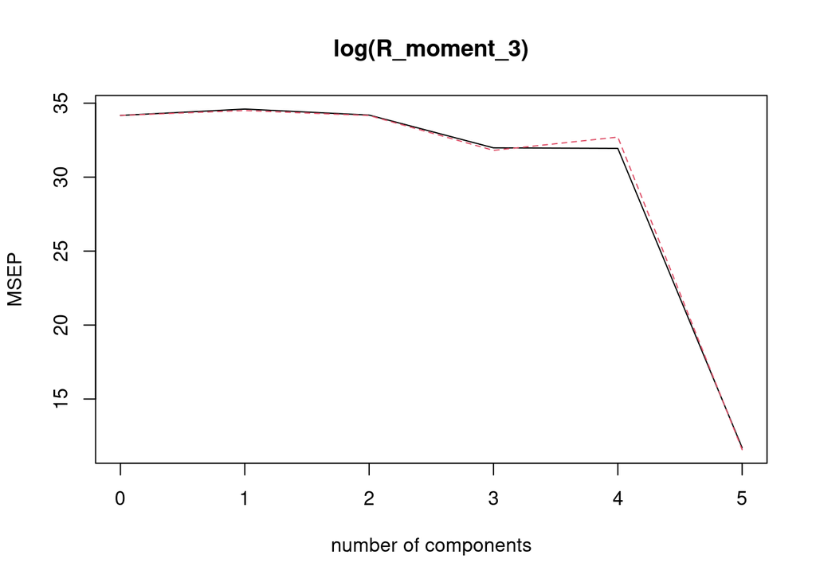

```r
fit3.pcr <- pcr(log(R_moment_3) ~ (St + factor(Re) + factor(Fr)), data = training, scale = TRUE, validation = "CV")
validationplot(fit3.pcr, val.type = "MSEP")
```

```r
pred3.pcr <- predict(fit3.pcr, testing, ncomp = 5)
mean((pred3.pcr - log(testing$R_moment_3))^2)
```

```
## [1] 10.6892
```

Same as least squares

Trying PLS on the 4th moment:

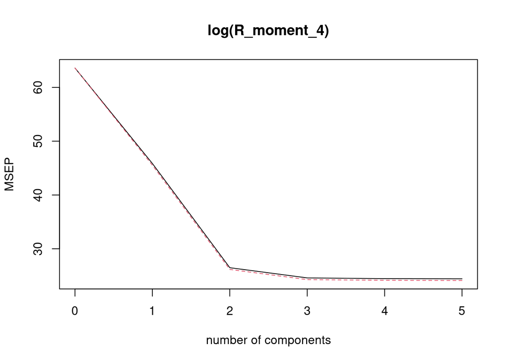

```r
fit4.pls <- plsr(log(R_moment_4) ~ (St + factor(Re) + factor(Fr)), data = training, validation = "CV")
validationplot(fit4.pls, val.type = "MSEP")
```

```r
predict4.pls<-predict(fit4.pls,testing,ncomp=5)
mean((predict4.pls - log(testing$R_moment_4))^2)
```

```
## [1] 21.32186
```

Same as least squares

# Regression Tree

```r
library(tree)
tree1 <- tree(R_moment_1 ~ St + factor(Re) + factor(Fr), data = training)
summary(tree1)
```

```
##
## Regression tree:
## tree(formula = R_moment_1 ~ St + factor(Re) + factor(Fr), data = training)
## Number of terminal nodes:  4
## Residual mean deviance:  8.062e-05 = 0.005402 / 67
## Distribution of residuals:
##       Min.    1st Qu.     Median       Mean    3rd Qu.       Max.
## -0.0355600 -0.0018170  0.0004226  0.0000000  0.0010840  0.0275500
```

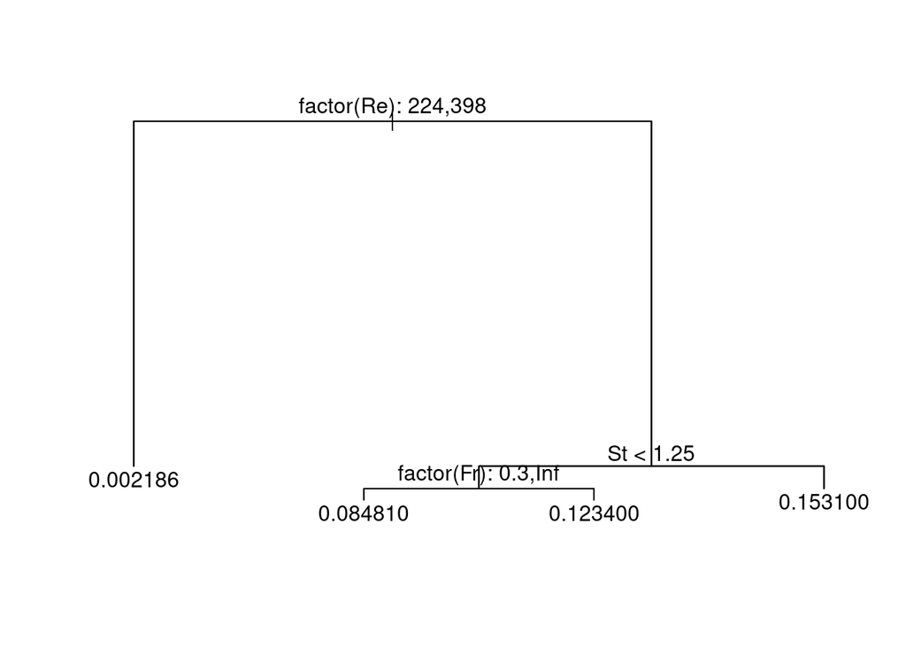

```r
plot(tree1)
text(tree1, pretty = 0)
```

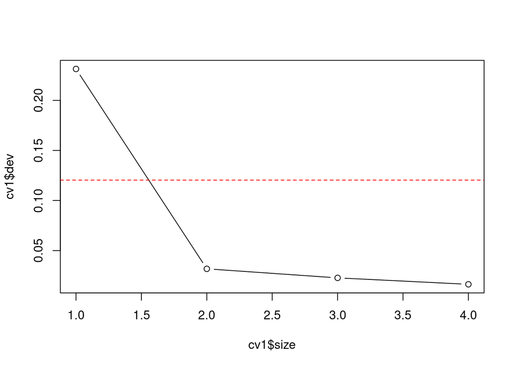

```r
cv1 <- cv.tree(tree1)
plot(cv1$size, cv1$dev, type = "b")
abline(h = min(cv1$dev) + 1 * sd(cv1$dev), col = "red", lty = 2)
```

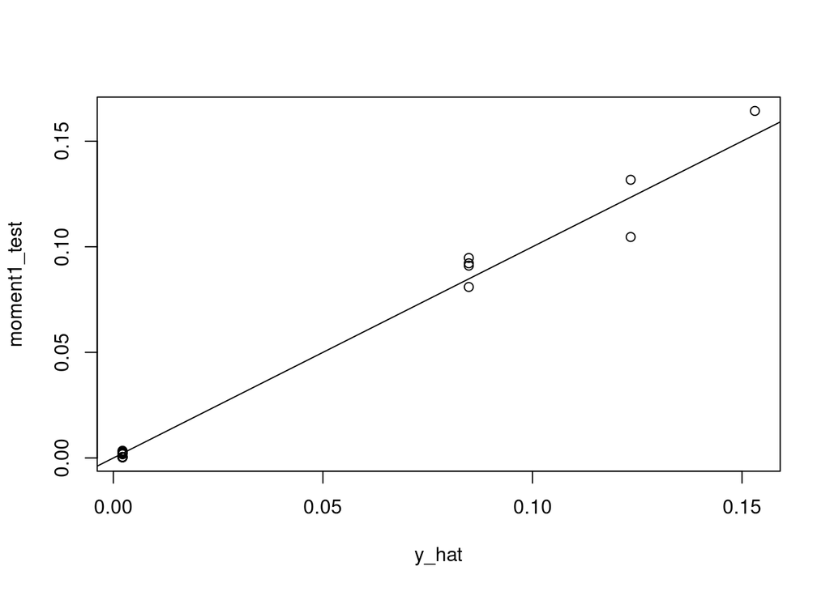

```r
y_hat <- predict(tree1, newdata = testing)
moment1_test <- testing[,"R_moment_1"]
plot(y_hat, moment1_test)
abline(0,1)
```

```r
test_error <- mean((y_hat-moment1_test)^2)
test_error
```

```
## [1] 4.301355e-05
```

```r
tss <- mean((testing$R_moment_1 - mean(testing$R_moment_1))^2)
(rss <- 1 - test_error / tss)
```

```
## [1] 0.9856966
```

# Regrssion tree does not work well on higher moments

```r
tree2 <- tree(R_moment_2 ~ St + factor(Re) + factor(Fr), data = training)
summary(tree2)
```

```
##
## Regression tree:
## tree(formula = R_moment_2 ~ St + factor(Re) + factor(Fr), data = training)
## Number of terminal nodes:  4
## Residual mean deviance:  5770 = 386600 / 67
## Distribution of residuals:
##      Min.   1st Qu.    Median      Mean   3rd Qu.      Max.
## -509.4000   -0.1063   -0.0687    0.0000    0.2122  208.2000
```

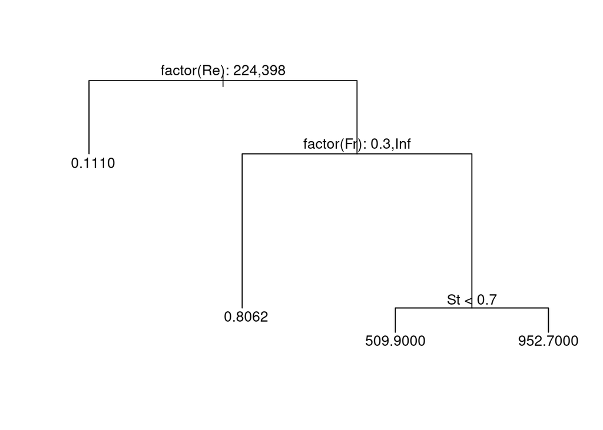

```r
plot(tree2)
text(tree2, pretty = 0)
```

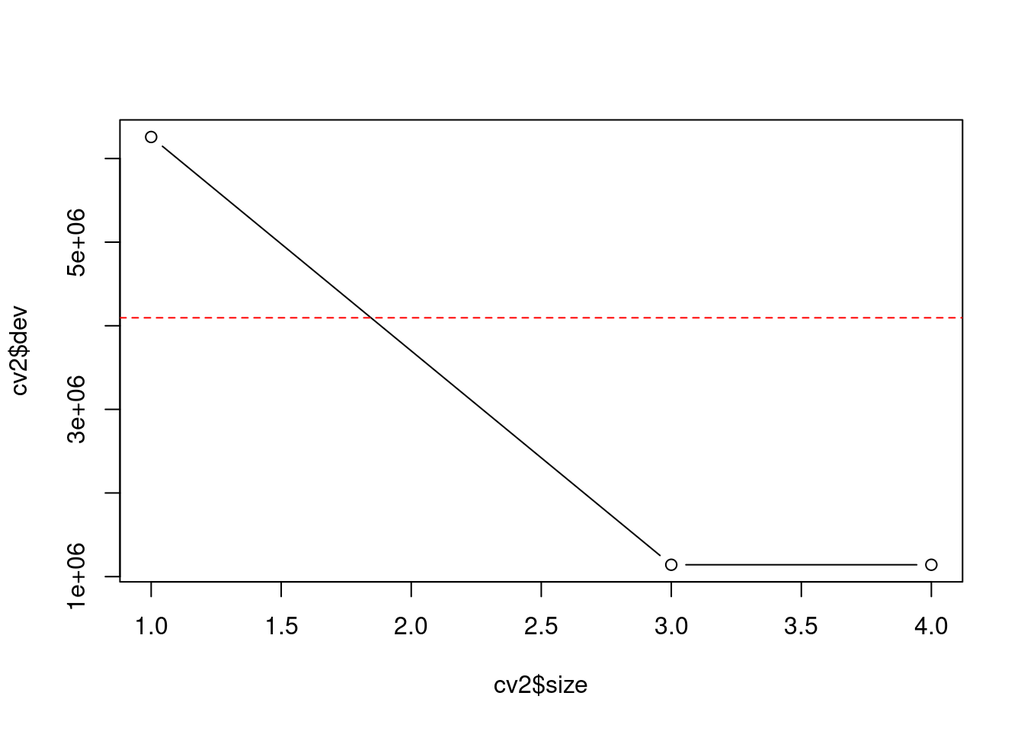

```r
cv2 <- cv.tree(tree2)
plot(cv2$size, cv2$dev, type = "b")
abline(h = min(cv2$dev) + 1 * sd(cv2$dev), col = "red", lty = 2)
```

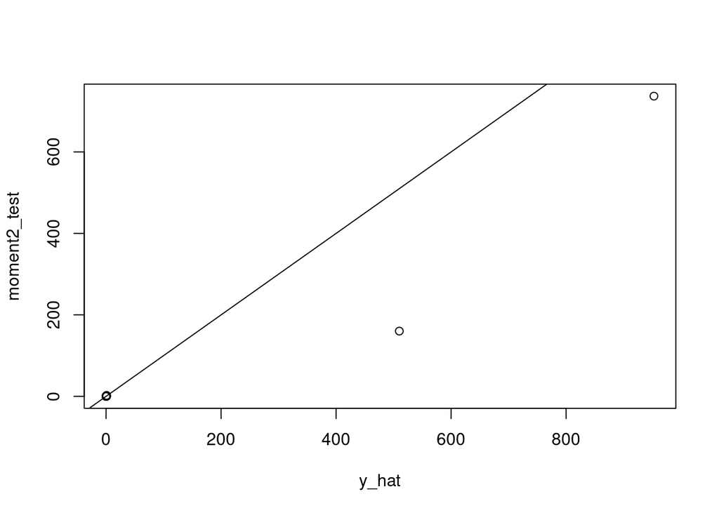

```r
y_hat <- predict(tree2, newdata = testing)
moment2_test <- testing[,"R_moment_2"]
plot(y_hat, moment2_test)
abline(0,1)
```

```r
(test_error <- mean((y_hat-moment2_test)^2))
```

```
## [1] 9383.652
```

```r
test_error
```

```
## [1] 9383.652
```

```r
tss <- mean((testing$R_moment_2 - mean(testing$R_moment_2))^2)
(rss <- 1 - test_error / tss)
```

```
## [1] 0.6773788
```

# Random Forest

```r
library(randomForest)
set.seed(120)
rf_mom2 <- randomForest(R_moment_2 ~ St + Re, data = training, ntree = 25,
                           importance = TRUE)
summary(rf_mom2)
```

```
##                 Length Class  Mode
## call             5     -none- call
## type             1     -none- character
## predicted       71     -none- numeric
## mse             25     -none- numeric
## rsq             25     -none- numeric
## oob.times       71     -none- numeric
## importance       4     -none- numeric
## importanceSD     2     -none- numeric
## localImportance  0     -none- NULL
## proximity        0     -none- NULL
## ntree            1     -none- numeric
## mtry             1     -none- numeric
## forest          11     -none- list
## coefs            0     -none- NULL
## y               71     -none- numeric
## test             0     -none- NULL
## inbag            0     -none- NULL
## terms            3     terms  call
```

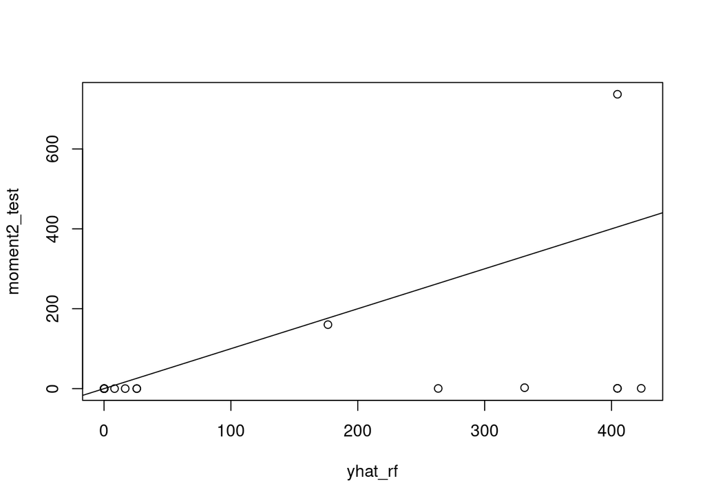

```r
yhat_rf <- predict(rf_mom2, newdata = testing)
plot(yhat_rf, moment2_test)
abline(0,1)
```

```r
mean((yhat_rf - moment2_test)^2)
```

```
## [1] 44173.13
```

```r
importance(rf_mom2)
```

```
##       %IncMSE IncNodePurity
## St -0.2015539      616978.4
## Re  5.6721342     1625450.9
```

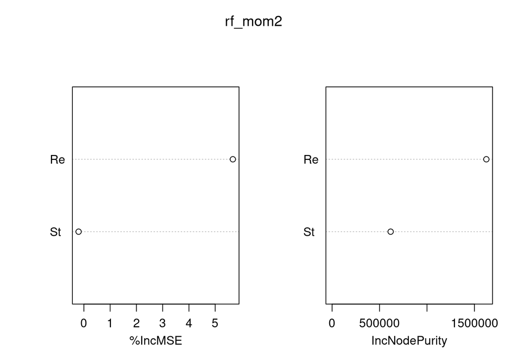

```r
varImpPlot(rf_mom2)
```

# Boosting doesn’t work

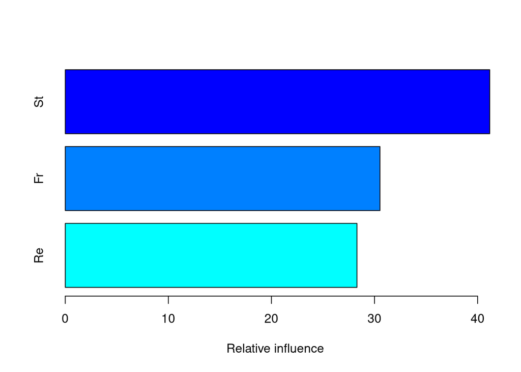

```
##    var  rel.inf
## St  St 41.17575
## Fr  Fr 30.52895
## Re  Re 28.29530
```

```r
library(gbm)
set.seed(8)
boost2 <- gbm(R_moment_2 ~ St + Re + Fr, data = training,
                      distribution = "gaussian", n.trees = 10000,
                      interaction.depth = 2)
?gbm()
summary(boost2)
```

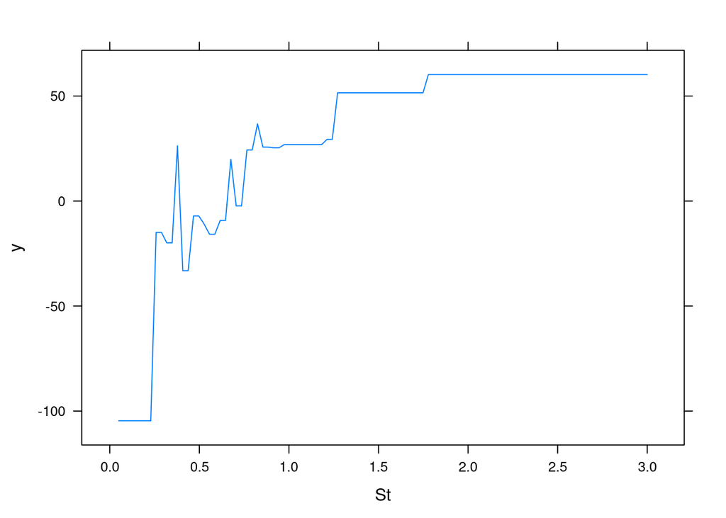

```r
# partial independence plots for Price and ShelveLoc
par(mfrow = c(1,3))
plot(boost2, i = "St")
```

```r
yhat_boost <- predict(boost2, newdata = testing,
                      n.trees = 5000)
mean((yhat_boost - moment2_test)^2)
```

```
## [1] 9993.697
```

## Box Cox Transformation for Moment 2

```r
library(car)
attach(data)
b2 <- boxCox(R_moment_2 ~ St + factor(Re) + factor(Fr))
```

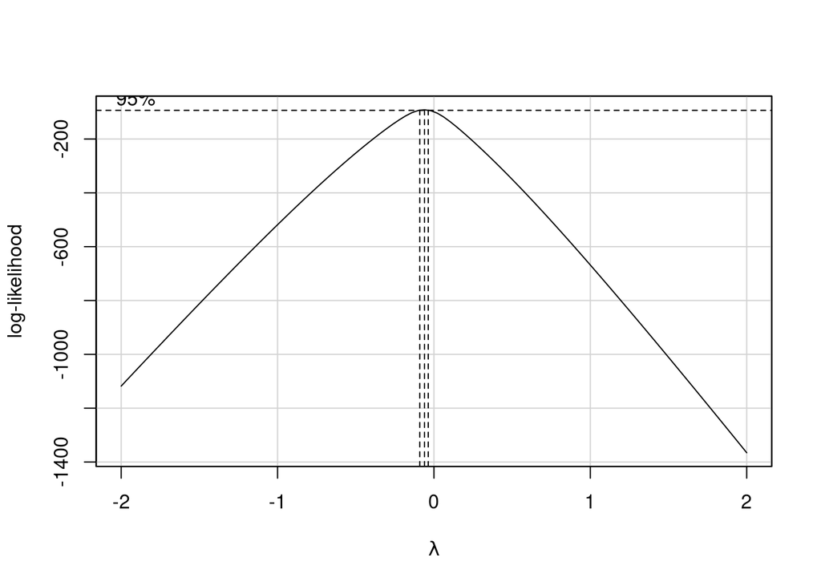

```r
lambda <- b2$x # lambda values

lik <- b2$y # log likelihood values for SSE

bc2 <- cbind(lambda, lik) # combine lambda and lik

sorted_bc2 <- bc2[order(-lik),] # values are sorted to identify the lambda value for the maximum log likelihood for obtaining minimum SSE

head(sorted_bc2, n = 10)
```

```
##            lambda        lik
##  [1,] -0.06060606  -91.48940
##  [2,] -0.10101010  -94.08486
##  [3,] -0.02020202  -94.68967
##  [4,] -0.14141414 -102.17650
##  [5,]  0.02020202 -103.63852
##  [6,] -0.18181818 -114.31060
##  [7,]  0.06060606 -117.46724
##  [8,] -0.22222222 -128.80389
##  [9,]  0.10101010 -134.48559
## [10,] -0.26262626 -144.67353
```

```r
mod2 <- lm(R_moment_2^(-0.06060606) ~ St + factor(Re) + factor(Fr))
summary(mod2)
```

```
##
## Call:
## lm(formula = R_moment_2^(-0.06060606) ~ St + factor(Re) + factor(Fr))
##
## Residuals:
##      Min       1Q   Median       3Q      Max
## -0.15406 -0.06746 -0.01750  0.06741  0.42720
##
## Coefficients:
##               Estimate Std. Error t value Pr(>|t|)
## (Intercept)    0.84601    0.02901  29.161  < 2e-16 ***
## St            -0.05051    0.01518  -3.326  0.00131 **
## factor(Re)224  0.27758    0.02691  10.317  < 2e-16 ***
## factor(Re)398  0.50219    0.03385  14.837  < 2e-16 ***
## factor(Fr)0.3  0.19611    0.03102   6.323 1.23e-08 ***
## factor(Fr)Inf  0.15451    0.02767   5.585 2.89e-07 ***
## ---
## Signif. codes:  0 '***' 0.001 '**' 0.01 '*' 0.05 '.' 0.1 ' ' 1
##
## Residual standard error: 0.1117 on 83 degrees of freedom
## Multiple R-squared:  0.7798, Adjusted R-squared:  0.7666
## F-statistic:  58.8 on 5 and 83 DF,  p-value: < 2.2e-16
```

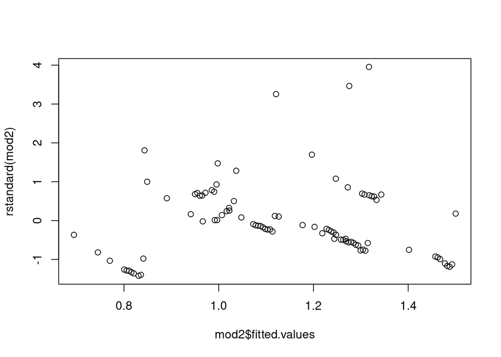

```r
plot(mod2$fitted.values,  rstandard(mod2))
```

## Box Cox Transformation for Moment 3

```r
b3 <- boxCox(R_moment_3 ~ St + factor(Re) + factor(Fr))
```

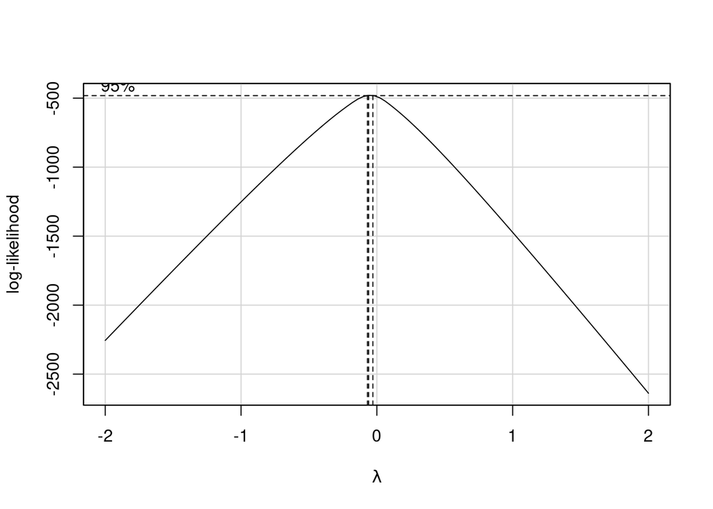

```r
lambda <- b3$x # lambda values

lik <- b3$y # log likelihood values for SSE

bc3 <- cbind(lambda, lik) # combine lambda and lik

sorted_bc3 <- bc3[order(-lik),] # values are sorted to identify the lambda value for the maximum log likelihood for obtaining minimum SSE

head(sorted_bc3, n = 10)
```

```
##            lambda       lik
##  [1,] -0.06060606 -479.8218
##  [2,] -0.02020202 -482.3179
##  [3,] -0.10101010 -488.5811
##  [4,]  0.02020202 -496.6415
##  [5,] -0.14141414 -507.3481
##  [6,]  0.06060606 -520.9426
##  [7,] -0.18181818 -532.7560
##  [8,]  0.10101010 -550.9501
##  [9,] -0.22222222 -561.0569
## [10,]  0.14141414 -583.0850
```

```r
mod3 <- lm(R_moment_3^(-0.06060606) ~ St + factor(Re) + factor(Fr))
summary(mod3)
```

```
##
## Call:
## lm(formula = R_moment_3^(-0.06060606) ~ St + factor(Re) + factor(Fr))
##
## Residuals:
##      Min       1Q   Median       3Q      Max
## -0.19459 -0.09524 -0.02489  0.09364  0.66813
##
## Coefficients:
##               Estimate Std. Error t value Pr(>|t|)
## (Intercept)    0.60491    0.03990  15.161  < 2e-16 ***
## St            -0.05747    0.02088  -2.752  0.00727 **
## factor(Re)224  0.25469    0.03700   6.883 1.03e-09 ***
## factor(Re)398  0.48788    0.04655  10.481  < 2e-16 ***
## factor(Fr)0.3  0.29460    0.04266   6.906 9.30e-10 ***
## factor(Fr)Inf  0.23249    0.03805   6.110 3.10e-08 ***
## ---
## Signif. codes:  0 '***' 0.001 '**' 0.01 '*' 0.05 '.' 0.1 ' ' 1
##
## Residual standard error: 0.1536 on 83 degrees of freedom
## Multiple R-squared:  0.6801, Adjusted R-squared:  0.6608
## F-statistic: 35.29 on 5 and 83 DF,  p-value: < 2.2e-16
```

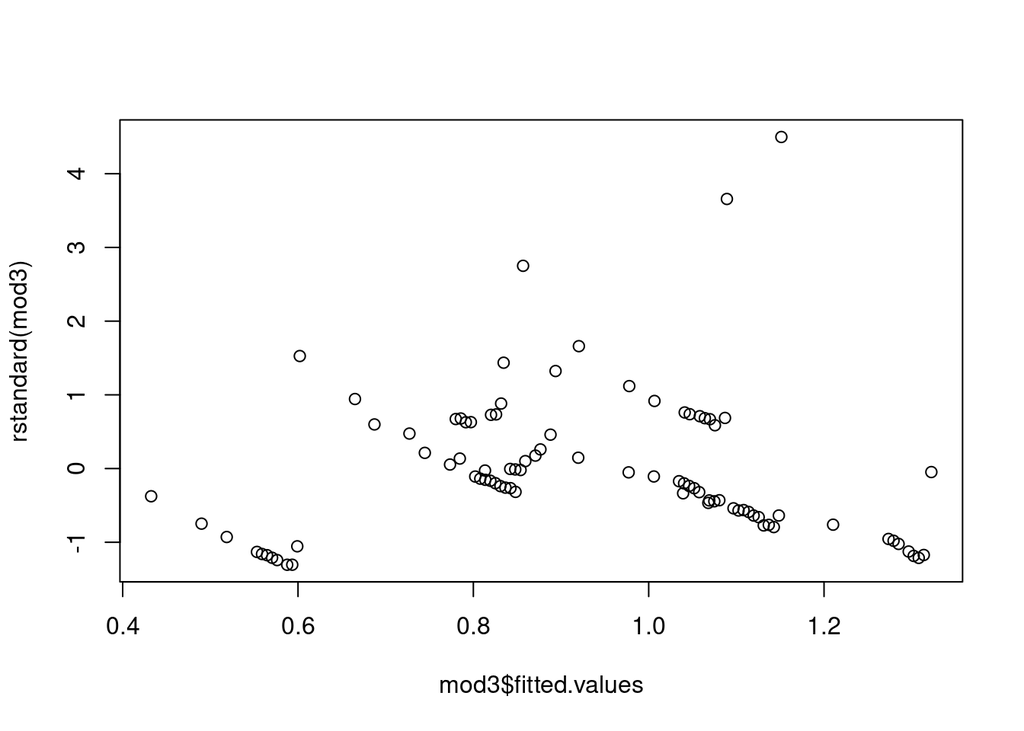

```r
plot(mod3$fitted.values,  rstandard(mod3))
```

## Box Cox Transformation for Moment 4

```r
b4 <- boxCox(R_moment_4 ~ St + factor(Re) + factor(Fr))
```

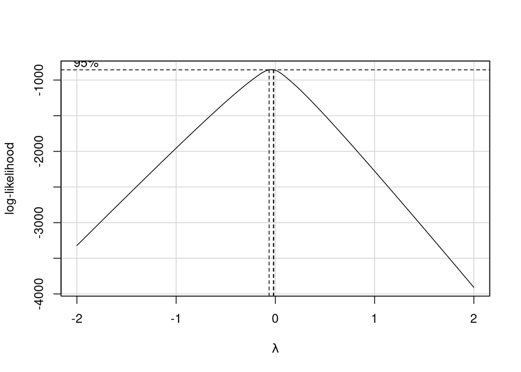

```r
lambda <- b4$x # lambda values

lik <- b4$y # log likelihood values for SSE

bc4 <- cbind(lambda, lik) # combine lambda and lik

sorted_bc4 <- bc4[order(-lik),] # values are sorted to identify the lambda value for the maximum log likelihood for obtaining minimum SSE

head(sorted_bc4, n = 10)
```

```
##            lambda        lik
##  [1,] -0.02020202  -854.7473
##  [2,] -0.06060606  -855.4489
##  [3,] -0.10101010  -872.8148
##  [4,]  0.02020202  -873.4229
##  [5,] -0.14141414  -903.4653
##  [6,]  0.06060606  -908.9295
##  [7,] -0.18181818  -942.3932
##  [8,]  0.10101010  -953.4615
##  [9,] -0.22222222  -984.3787
## [10,]  0.14141414 -1000.5431
```

```r
mod4 <- lm(R_moment_4^(-0.02020202) ~ St + factor(Re) + factor(Fr))

glm <- glm(R_moment_4 ~ St + factor(Re) + factor(Fr), data = data, family = Gamma("inverse"))
summary(glm)
```

```
##
## Call:
## glm(formula = R_moment_4 ~ St + factor(Re) + factor(Fr), family = Gamma("inverse"),
##     data = data)
##
## Deviance Residuals:
##     Min       1Q   Median       3Q      Max
## -5.6282  -1.2163  -0.2102   0.2285   3.8001
##
## Coefficients:
##                 Estimate Std. Error t value Pr(>|t|)
## (Intercept)    3.142e-11  1.574e-11   1.996  0.04922 *
## St            -7.588e-12  7.329e-12  -1.035  0.30353
## factor(Re)224  1.625e-04  6.380e-05   2.547  0.01271 *
## factor(Re)398  4.746e-01  1.621e-01   2.927  0.00442 **
## factor(Fr)0.3  7.166e-03  2.224e-03   3.223  0.00181 **
## factor(Fr)Inf  1.388e-02  4.481e-03   3.099  0.00265 **
## ---
## Signif. codes:  0 '***' 0.001 '**' 0.01 '*' 0.05 '.' 0.1 ' ' 1
##
## (Dispersion parameter for Gamma family taken to be 2.158833)
##
##     Null deviance: 2953.46  on 88  degrees of freedom
## Residual deviance:  205.54  on 83  degrees of freedom
## AIC: 1431.9
##
## Number of Fisher Scoring iterations: 8
```

```r
original <- data[, "R_moment_4"]

after_transformation <- glm$fitted.values

back_transformation <- glm$fitted.values^(1/-0.02020202)

fittedvalues <- data.frame(original, after_transformation, back_transformation)

head(fittedvalues, n = 10)
```

```
##      original after_transformation back_transformation
## 1   1586.5000          6154.626988       2.719645e-188
## 2  10404.0000          6154.627821       2.719626e-188
## 3     15.5510            71.191385        2.017626e-92
## 4      3.2696            72.024502        1.134295e-92
## 5      2.5714             2.047302        3.949030e-16
## 6    671.6700           139.541849       6.872702e-107
## 7     32.9760            72.024502        1.134295e-92
## 8     63.1590            71.191385        2.017626e-92
## 9     15.8090            71.191385        2.017626e-92
## 10     1.5077             2.107200        9.474734e-17
```

```r
fittedvalues
```

```
##      original after_transformation back_transformation
## 1  1.5865e+03         6.154627e+03       2.719645e-188
## 2  1.0404e+04         6.154628e+03       2.719626e-188
## 3  1.5551e+01         7.119139e+01        2.017626e-92
## 4  3.2696e+00         7.202450e+01        1.134295e-92
## 5  2.5714e+00         2.047302e+00        3.949030e-16
## 6  6.7167e+02         1.395418e+02       6.872702e-107
## 7  3.2976e+01         7.202450e+01        1.134295e-92
## 8  6.3159e+01         7.119139e+01        2.017626e-92
## 9  1.5809e+01         7.119139e+01        2.017626e-92
## 10 1.5077e+00         2.107200e+00        9.474734e-17
## 11 9.5166e+01         7.202450e+01        1.134295e-92
## 12 2.9211e+00         2.047302e+00        3.949030e-16
## 13 3.4408e+01         7.119139e+01        2.017626e-92
## 14 7.7958e+03         6.154627e+03       2.719639e-188
```

[output cut: 75 more lines]

```r
y_hat_glm <- predict(glm, newdata = testing)
y_hat_glm
```

```
##           24           27           30           32           35           39
## 4.745634e-01 4.745634e-01 1.624794e-04 1.388416e-02 1.404664e-02 7.328788e-03
##           42           47           49           50           53           56
## 7.328788e-03 7.166309e-03 7.328788e-03 7.328788e-03 4.884476e-01 4.745634e-01
##           57           64           65           79           83           85
## 1.388416e-02 4.884476e-01 2.611270e-11 3.066538e-11 7.166309e-03 7.166309e-03
```

```r
testing$R_moment_4
```

```
##  [1] 2.1004e+00 1.0344e+00 3.6438e-01 9.7048e+01 1.5759e+01 1.9340e+01
##  [7] 1.3132e+01 1.3187e+02 1.4966e+01 7.2842e+00 4.4109e+00 1.4770e+00
## [13] 8.8723e+01 2.3884e+00 4.6700e+10 3.0700e+09 5.3618e+01 8.8779e+02
```

```r
cbind(y_hat_glm^(1/-.02), testing$R_moment_4)
```

```
##             [,1]       [,2]
## 24  1.532095e+16 2.1004e+00
## 27  1.532095e+16 1.0344e+00
## 30 2.884608e+189 3.6438e-01
## 32  7.481923e+92 9.7048e+01
## 35  4.181886e+92 1.5759e+01
## 39 5.602620e+106 1.9340e+01
## 42 5.602620e+106 1.3132e+01
## 47 1.718793e+107 1.3187e+02
## 49 5.602620e+106 1.4966e+01
## 50 5.602620e+106 7.2842e+00
## 53  3.623267e+15 4.4109e+00
## 56  1.532095e+16 1.4770e+00
## 57  7.481923e+92 8.8723e+01
## 64  3.623267e+15 2.3884e+00
## 65           Inf 4.6700e+10
## 79           Inf 3.0700e+09
## 83 1.718793e+107 5.3618e+01
## 85 1.718794e+107 8.8779e+02
```

```r
moment4_test <- testing[,"R_moment_4"]
y_hat_glm
```

```
##           24           27           30           32           35           39
## 4.745634e-01 4.745634e-01 1.624794e-04 1.388416e-02 1.404664e-02 7.328788e-03
##           42           47           49           50           53           56
## 7.328788e-03 7.166309e-03 7.328788e-03 7.328788e-03 4.884476e-01 4.745634e-01
##           57           64           65           79           83           85
## 1.388416e-02 4.884476e-01 2.611270e-11 3.066538e-11 7.166309e-03 7.166309e-03
```

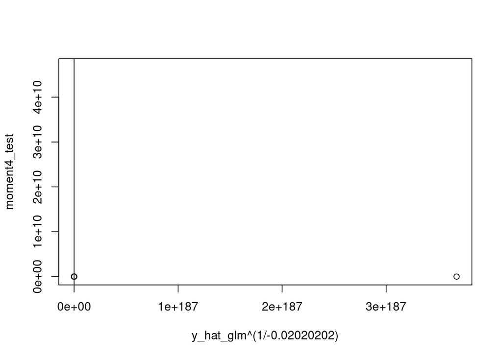

```r
plot(y_hat_glm^(1/-0.02020202), moment4_test)
abline(0,1)
```

```r
(test_error <- mean((y_hat_glm-moment4_test)^2))
```

```
## [1] 1.216842e+20
```

```r
tss <- mean((testing$R_moment_2 - mean(testing$R_moment_2))^2)
(rss <- 1 - test_error / tss)
```

```
## [1] -4.183647e+15
```

```r
summary(mod4)
```

```
##
## Call:
## lm(formula = R_moment_4^(-0.02020202) ~ St + factor(Re) + factor(Fr))
##
## Residuals:
##       Min        1Q    Median        3Q       Max
## -0.116144 -0.048959  0.000599  0.057209  0.216084
##
## Coefficients:
##               Estimate Std. Error t value Pr(>|t|)
## (Intercept)    0.73372    0.01916  38.302  < 2e-16 ***
## St            -0.02141    0.01003  -2.135   0.0357 *
## factor(Re)224  0.11311    0.01777   6.367 1.01e-08 ***
## factor(Re)398  0.21053    0.02235   9.420 9.44e-15 ***
## factor(Fr)0.3  0.16419    0.02048   8.017 6.02e-12 ***
## factor(Fr)Inf  0.13159    0.01827   7.203 2.45e-10 ***
## ---
## Signif. codes:  0 '***' 0.001 '**' 0.01 '*' 0.05 '.' 0.1 ' ' 1
##
## Residual standard error: 0.07376 on 83 degrees of freedom
## Multiple R-squared:  0.6751, Adjusted R-squared:  0.6555
## F-statistic: 34.49 on 5 and 83 DF,  p-value: < 2.2e-16
```

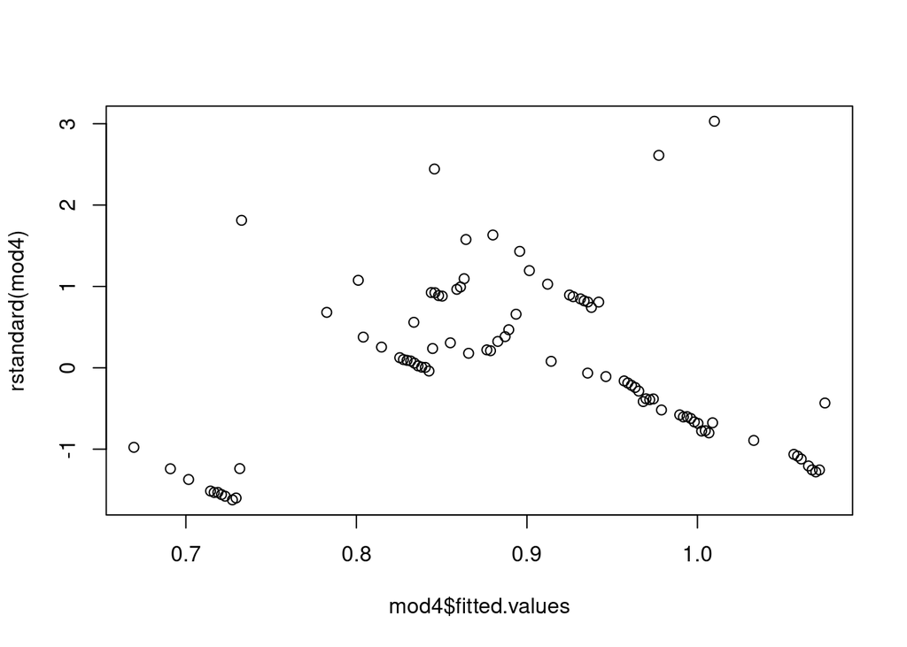

```r
plot(mod4$fitted.values,  rstandard(mod4))
```

# Zero-Inflated Model

```r
library(pscl)
data_trunc <- data
attach(data_trunc)
data_trunc$R_moment_1 <- ifelse(R_moment_1 < 0.05, 0, round(R_moment_1, 0))
data_trunc$R_moment_2 <- ifelse(R_moment_2 < 1, 0, round(R_moment_2, 0))
data_trunc$R_moment_3 <- ifelse(R_moment_3 < 10, 0, round(R_moment_3, 0))
data_trunc$R_moment_4 <- ifelse(R_moment_4 < 10^2, 0, round(R_moment_4, 0))
data_trunc
```

```
##      St  Re    Fr R_moment_1 R_moment_2 R_moment_3 R_moment_4
## 1  0.10 224 0.052          0          0         14 1.5860e+03
## 2  3.00 224 0.052          0          0         70 1.0404e+04
## 3  0.70 224   Inf          0          0          0 0.0000e+00
## 4  0.05  90   Inf          0          0          0 0.0000e+00
## 5  0.70 398   Inf          0          0          0 0.0000e+00
## 6  2.00  90 0.300          0          2         36 6.7200e+02
## 7  0.20  90   Inf          0          0          0 0.0000e+00
## 8  3.00 224   Inf          0          0          0 0.0000e+00
## 9  0.90 224   Inf          0          0          0 0.0000e+00
## 10 0.60 398 0.052          0          0          0 0.0000e+00
## 11 0.90  90   Inf          0          0          0 0.0000e+00
## 12 0.30 398   Inf          0          0          0 0.0000e+00
## 13 2.00 224   Inf          0          0          0 0.0000e+00
## 14 1.00 224 0.052          0          0         53 7.7960e+03
```

[output cut: 75 more lines]

```r
#m1 <- zeroinfl(R_moment_4 ~ St + factor(Re) + factor(Fr), data = data_trunc)
```

## Polynomial Regression

For each of the four moments, we try to fit a polynomial model based on the degree of the numerical variable, St. We also include the other two factored variables in each model.

First moment:

```r
polym1 <- lm(log(R_moment_1) ~ poly(St, 2) + factor(Re) + factor(Fr), data = training)
summary(polym1)
```

```
##
## Call:
## lm(formula = log(R_moment_1) ~ poly(St, 2) + factor(Re) + factor(Fr),
##     data = training)
##
## Residuals:
##      Min       1Q   Median       3Q      Max
## -0.33265 -0.06610  0.00707  0.07555  0.34096
##
## Coefficients:
##               Estimate Std. Error  t value Pr(>|t|)
## (Intercept)   -2.16637    0.03629  -59.702  < 2e-16 ***
## poly(St, 2)1   1.58953    0.14605   10.884 3.38e-16 ***
## poly(St, 2)2  -0.68385    0.14764   -4.632 1.83e-05 ***
## factor(Re)224 -3.64684    0.03907  -93.344  < 2e-16 ***
## factor(Re)398 -5.79385    0.05059 -114.522  < 2e-16 ***
## factor(Fr)0.3 -0.15091    0.04656   -3.241  0.00189 **
## factor(Fr)Inf -0.02023    0.03967   -0.510  0.61171
## ---
## Signif. codes:  0 '***' 0.001 '**' 0.01 '*' 0.05 '.' 0.1 ' ' 1
##
## Residual standard error: 0.1448 on 64 degrees of freedom
## Multiple R-squared:  0.996,  Adjusted R-squared:  0.9957
## F-statistic:  2677 on 6 and 64 DF,  p-value: < 2.2e-16
```

```r
poly2m1 <- lm(log(R_moment_1) ~ poly(St, 3) + factor(Re) + factor(Fr), data = training)
summary(poly2m1)
```

```
##
## Call:
## lm(formula = log(R_moment_1) ~ poly(St, 3) + factor(Re) + factor(Fr),
##     data = training)
##
## Residuals:
##      Min       1Q   Median       3Q      Max
## -0.31477 -0.07409 -0.00261  0.09929  0.30537
##
## Coefficients:
##               Estimate Std. Error  t value Pr(>|t|)
## (Intercept)   -2.16241    0.03558  -60.781  < 2e-16 ***
## poly(St, 3)1   1.58984    0.14296   11.121  < 2e-16 ***
## poly(St, 3)2  -0.68415    0.14452   -4.734 1.29e-05 ***
## poly(St, 3)3   0.28014    0.14378    1.948  0.05583 .
## factor(Re)224 -3.65344    0.03839  -95.161  < 2e-16 ***
## factor(Re)398 -5.80718    0.04999 -116.163  < 2e-16 ***
## factor(Fr)0.3 -0.14556    0.04565   -3.188  0.00223 **
## factor(Fr)Inf -0.01874    0.03883   -0.482  0.63117
## ---
## Signif. codes:  0 '***' 0.001 '**' 0.01 '*' 0.05 '.' 0.1 ' ' 1
##
## Residual standard error: 0.1418 on 63 degrees of freedom
## Multiple R-squared:  0.9963, Adjusted R-squared:  0.9958
## F-statistic:  2395 on 7 and 63 DF,  p-value: < 2.2e-16
```

```r
poly3m1 <- lm(log(R_moment_1) ~ poly(St, 4) + factor(Re) + factor(Fr), data = training)
summary(poly3m1)
```

```
##
## Call:
## lm(formula = log(R_moment_1) ~ poly(St, 4) + factor(Re) + factor(Fr),
##     data = training)
##
## Residuals:
##      Min       1Q   Median       3Q      Max
## -0.29739 -0.06934 -0.01242  0.08023  0.31329
##
## Coefficients:
##                Estimate Std. Error  t value Pr(>|t|)
## (Intercept)   -2.157680   0.032765  -65.852  < 2e-16 ***
## poly(St, 4)1   1.594005   0.131556   12.117  < 2e-16 ***
## poly(St, 4)2  -0.693114   0.133013   -5.211 2.28e-06 ***
## poly(St, 4)3   0.294630   0.132369    2.226 0.029671 *
## poly(St, 4)4  -0.470535   0.133620   -3.521 0.000811 ***
## factor(Re)224 -3.667027   0.035538 -103.185  < 2e-16 ***
## factor(Re)398 -5.836580   0.046754 -124.837  < 2e-16 ***
## factor(Fr)0.3 -0.137911   0.042067   -3.278 0.001714 **
## factor(Fr)Inf -0.002662   0.036025   -0.074 0.941342
## ---
## Signif. codes:  0 '***' 0.001 '**' 0.01 '*' 0.05 '.' 0.1 ' ' 1
##
## Residual standard error: 0.1304 on 62 degrees of freedom
## Multiple R-squared:  0.9969, Adjusted R-squared:  0.9965
## F-statistic:  2476 on 8 and 62 DF,  p-value: < 2.2e-16
```

```r
poly4m1 <- lm(log(R_moment_1) ~ poly(St, 5) + factor(Re) + factor(Fr), data = training)
summary(poly4m1)
```

```
##
## Call:
## lm(formula = log(R_moment_1) ~ poly(St, 5) + factor(Re) + factor(Fr),
##     data = training)
##
## Residuals:
##       Min        1Q    Median        3Q       Max
## -0.315418 -0.067990 -0.005822  0.075227  0.307888
##
## Coefficients:
##                 Estimate Std. Error  t value Pr(>|t|)
## (Intercept)   -2.1666151  0.0312280  -69.380  < 2e-16 ***
## poly(St, 5)1   1.5983470  0.1247464   12.813  < 2e-16 ***
## poly(St, 5)2  -0.6871726  0.1261360   -5.448 9.67e-07 ***
## poly(St, 5)3   0.2913410  0.1255131    2.321 0.023634 *
## poly(St, 5)4  -0.4660782  0.1267042   -3.678 0.000498 ***
## poly(St, 5)5   0.3524325  0.1248844    2.822 0.006433 **
## factor(Re)224 -3.6617252  0.0337487 -108.500  < 2e-16 ***
## factor(Re)398 -5.8223510  0.0446161 -130.499  < 2e-16 ***
## factor(Fr)0.3 -0.1266630  0.0400856   -3.160 0.002457 **
## factor(Fr)Inf  0.0005497  0.0341770    0.016 0.987219
## ---
## Signif. codes:  0 '***' 0.001 '**' 0.01 '*' 0.05 '.' 0.1 ' ' 1
##
## Residual standard error: 0.1237 on 61 degrees of freedom
## Multiple R-squared:  0.9972, Adjusted R-squared:  0.9968
## F-statistic:  2449 on 9 and 61 DF,  p-value: < 2.2e-16
```

```r
poly5m1 <- lm(log(R_moment_1) ~ poly(St, 6) + factor(Re) + factor(Fr), data = training)
summary(poly5m1)
```

```
##
## Call:
## lm(formula = log(R_moment_1) ~ poly(St, 6) + factor(Re) + factor(Fr),
##     data = training)
##
## Residuals:
##      Min       1Q   Median       3Q      Max
## -0.32045 -0.06636 -0.00751  0.07647  0.30827
##
## Coefficients:
##                 Estimate Std. Error  t value Pr(>|t|)
## (Intercept)   -2.1675450  0.0314175  -68.992  < 2e-16 ***
## poly(St, 6)1   1.5979933  0.1253666   12.747  < 2e-16 ***
## poly(St, 6)2  -0.6862440  0.1267703   -5.413 1.14e-06 ***
## poly(St, 6)3   0.2895551  0.1261676    2.295  0.02525 *
## poly(St, 6)4  -0.4636290  0.1273919   -3.639  0.00057 ***
## poly(St, 6)5   0.3531189  0.1255088    2.814  0.00662 **
## poly(St, 6)6  -0.0793434  0.1255883   -0.632  0.52993
## factor(Re)224 -3.6596637  0.0340727 -107.407  < 2e-16 ***
## factor(Re)398 -5.8189474  0.0451600 -128.852  < 2e-16 ***
## factor(Fr)0.3 -0.1276059  0.0403121   -3.165  0.00243 **
## factor(Fr)Inf -0.0008333  0.0344162   -0.024  0.98076
## ---
## Signif. codes:  0 '***' 0.001 '**' 0.01 '*' 0.05 '.' 0.1 ' ' 1
##
## Residual standard error: 0.1243 on 60 degrees of freedom
## Multiple R-squared:  0.9973, Adjusted R-squared:  0.9968
## F-statistic:  2183 on 10 and 60 DF,  p-value: < 2.2e-16
```

```r
poly6m1 <- lm(log(R_moment_1) ~ poly(St, 7) + factor(Re) + factor(Fr), data = training)
summary(poly6m1)
```

```
##
## Call:
## lm(formula = log(R_moment_1) ~ poly(St, 7) + factor(Re) + factor(Fr),
##     data = training)
##
## Residuals:
##       Min        1Q    Median        3Q       Max
## -0.314045 -0.057152 -0.008371  0.071402  0.306723
##
## Coefficients:
##                Estimate Std. Error  t value Pr(>|t|)
## (Intercept)   -2.169020   0.031474  -68.915  < 2e-16 ***
## poly(St, 7)1   1.599136   0.125448   12.747  < 2e-16 ***
## poly(St, 7)2  -0.687297   0.126852   -5.418 1.17e-06 ***
## poly(St, 7)3   0.288807   0.126246    2.288 0.025759 *
## poly(St, 7)4  -0.463958   0.127469   -3.640 0.000576 ***
## poly(St, 7)5   0.353746   0.125586    2.817 0.006588 **
## poly(St, 7)6  -0.079363   0.125664   -0.632 0.530121
## poly(St, 7)7   0.120345   0.124960    0.963 0.339446
## factor(Re)224 -3.659404   0.034094 -107.332  < 2e-16 ***
## factor(Re)398 -5.817566   0.045210 -128.679  < 2e-16 ***
## factor(Fr)0.3 -0.127109   0.040340   -3.151 0.002556 **
## factor(Fr)Inf  0.001922   0.034556    0.056 0.955824
## ---
## Signif. codes:  0 '***' 0.001 '**' 0.01 '*' 0.05 '.' 0.1 ' ' 1
##
## Residual standard error: 0.1244 on 59 degrees of freedom
## Multiple R-squared:  0.9973, Adjusted R-squared:  0.9968
## F-statistic:  1982 on 11 and 59 DF,  p-value: < 2.2e-16
```

```r
poly7m1 <- lm(log(R_moment_1) ~ poly(St, 8) + factor(Re) + factor(Fr), data = training)
summary(poly7m1)
```

```
##
## Call:
## lm(formula = log(R_moment_1) ~ poly(St, 8) + factor(Re) + factor(Fr),
##     data = training)
##
## Residuals:
##      Min       1Q   Median       3Q      Max
## -0.32396 -0.06248 -0.00834  0.07358  0.30616
##
## Coefficients:
##                Estimate Std. Error  t value Pr(>|t|)
## (Intercept)   -2.168615   0.031700  -68.411  < 2e-16 ***
## poly(St, 8)1   1.599062   0.126300   12.661  < 2e-16 ***
## poly(St, 8)2  -0.686162   0.127737   -5.372 1.44e-06 ***
## poly(St, 8)3   0.291206   0.127213    2.289 0.025731 *
## poly(St, 8)4  -0.466124   0.128423   -3.630 0.000601 ***
## poly(St, 8)5   0.353233   0.126444    2.794 0.007052 **
## poly(St, 8)6  -0.077942   0.126556   -0.616 0.540390
## poly(St, 8)7   0.119490   0.125823    0.950 0.346220
## poly(St, 8)8   0.059253   0.130219    0.455 0.650787
## factor(Re)224 -3.659571   0.034328 -106.607  < 2e-16 ***
## factor(Re)398 -5.821425   0.046300 -125.733  < 2e-16 ***
## factor(Fr)0.3 -0.124911   0.040900   -3.054 0.003406 **
## factor(Fr)Inf  0.001746   0.034792    0.050 0.960145
## ---
## Signif. codes:  0 '***' 0.001 '**' 0.01 '*' 0.05 '.' 0.1 ' ' 1
##
## Residual standard error: 0.1252 on 58 degrees of freedom
## Multiple R-squared:  0.9973, Adjusted R-squared:  0.9968
## F-statistic:  1793 on 12 and 58 DF,  p-value: < 2.2e-16
```

```r
anova(fit.lm1, polym1, poly2m1, poly3m1, poly4m1, poly5m1, poly6m1, poly7m1)
```

```
## Analysis of Variance Table
##
## Model 1: log(R_moment_1) ~ (St + factor(Re) + factor(Fr) + factor(Re) *
##     factor(Fr))
## Model 2: log(R_moment_1) ~ poly(St, 2) + factor(Re) + factor(Fr)
## Model 3: log(R_moment_1) ~ poly(St, 3) + factor(Re) + factor(Fr)
## Model 4: log(R_moment_1) ~ poly(St, 4) + factor(Re) + factor(Fr)
## Model 5: log(R_moment_1) ~ poly(St, 5) + factor(Re) + factor(Fr)
## Model 6: log(R_moment_1) ~ poly(St, 6) + factor(Re) + factor(Fr)
## Model 7: log(R_moment_1) ~ poly(St, 7) + factor(Re) + factor(Fr)
## Model 8: log(R_moment_1) ~ poly(St, 8) + factor(Re) + factor(Fr)
##   Res.Df     RSS Df Sum of Sq       F    Pr(>F)
## 1     62 1.24014
## 2     64 1.34226 -2 -0.102123  3.2567 0.0456642 *
## 3     63 1.26598  1  0.076284  4.8654 0.0313772 *
## 4     62 1.05498  1  0.211003 13.4576 0.0005319 ***
## 5     61 0.93315  1  0.121830  7.7702 0.0071691 **
## 6     60 0.92698  1  0.006167  0.3933 0.5330320
## 7     59 0.91263  1  0.014347  0.9150 0.3427539
## 8     58 0.90939  1  0.003246  0.2071 0.6507871
## ---
## Signif. codes:  0 '***' 0.001 '**' 0.01 '*' 0.05 '.' 0.1 ' ' 1
```

```r
pred.polym1 <- predict(polym1, testing)
pred.poly2m1 <- predict(poly2m1, testing)
pred.poly3m1 <- predict(poly3m1, testing)
pred.poly4m1 <- predict(poly4m1, testing)
pred.poly5m1 <- predict(poly5m1, testing)
pred.poly6m1 <- predict(poly6m1, testing)
pred.poly7m1 <- predict(poly7m1, testing)

mse_polym1 <- mean((pred.polym1 - log(testing$R_moment_1))^2)
mse_poly2m1 <- mean((pred.poly2m1 - log(testing$R_moment_1))^2)
mse_poly3m1 <- mean((pred.poly3m1 - log(testing$R_moment_1))^2)
mse_poly4m1 <- mean((pred.poly4m1 - log(testing$R_moment_1))^2)
mse_poly5m1 <- mean((pred.poly5m1 - log(testing$R_moment_1))^2)
mse_poly6m1 <- mean((pred.poly6m1 - log(testing$R_moment_1))^2)
mse_poly7m1 <- mean((pred.poly7m1 - log(testing$R_moment_1))^2)

mse_polym1
```

```
## [1] 0.02244211
```

```r
mse_poly2m1
```

```
## [1] 0.0250986
```

```r
mse_poly3m1
```

```
## [1] 0.027301
```

```r
mse_poly4m1
```

```
## [1] 0.02443886
```

```r
mse_poly5m1
```

```
## [1] 0.02302476
```

```r
mse_poly6m1
```

```
## [1] 0.02203137
```

```r
mse_poly7m1
```

```
## [1] 0.02338871
```

Similar to least squares.

Second moment:

```r
polym2 <- lm(log(R_moment_2) ~ poly(St, 2) + factor(Re) + factor(Fr), data = training)
summary(polym2)
```

```
##
## Call:
## lm(formula = log(R_moment_2) ~ poly(St, 2) + factor(Re) + factor(Fr),
##     data = training)
##
## Residuals:
##     Min      1Q  Median      3Q     Max
## -3.2423 -1.0935 -0.1559  1.2966  3.1722
##
## Coefficients:
##               Estimate Std. Error t value Pr(>|t|)
## (Intercept)     4.1076     0.4209   9.758 2.74e-14 ***
## poly(St, 2)1    4.6783     1.6942   2.761  0.00750 **
## poly(St, 2)2   -5.4282     1.7128  -3.169  0.00234 **
## factor(Re)224  -4.8151     0.4532 -10.624 9.20e-16 ***
## factor(Re)398  -7.9846     0.5869 -13.605  < 2e-16 ***
## factor(Fr)0.3  -3.9073     0.5401  -7.235 7.20e-10 ***
## factor(Fr)Inf  -2.8244     0.4601  -6.138 5.87e-08 ***
## ---
## Signif. codes:  0 '***' 0.001 '**' 0.01 '*' 0.05 '.' 0.1 ' ' 1
##
## Residual standard error: 1.68 on 64 degrees of freedom
## Multiple R-squared:  0.8171, Adjusted R-squared:    0.8
## F-statistic: 47.65 on 6 and 64 DF,  p-value: < 2.2e-16
```

```r
poly2m2 <- lm(log(R_moment_2) ~ poly(St, 3) + factor(Re) + factor(Fr), data = training)
summary(poly2m2)
```

```
##
## Call:
## lm(formula = log(R_moment_2) ~ poly(St, 3) + factor(Re) + factor(Fr),
##     data = training)
##
## Residuals:
##     Min      1Q  Median      3Q     Max
## -2.7756 -1.1822 -0.1902  1.1267  3.3059
##
## Coefficients:
##               Estimate Std. Error t value Pr(>|t|)
## (Intercept)     4.1625     0.4073  10.219 5.34e-15 ***
## poly(St, 3)1    4.6826     1.6368   2.861  0.00573 **
## poly(St, 3)2   -5.4325     1.6547  -3.283  0.00168 **
## poly(St, 3)3    3.8863     1.6462   2.361  0.02134 *
## factor(Re)224  -4.9066     0.4396 -11.163  < 2e-16 ***
## factor(Re)398  -8.1695     0.5724 -14.273  < 2e-16 ***
## factor(Fr)0.3  -3.8331     0.5227  -7.333 5.24e-10 ***
## factor(Fr)Inf  -2.8036     0.4446  -6.306 3.19e-08 ***
## ---
## Signif. codes:  0 '***' 0.001 '**' 0.01 '*' 0.05 '.' 0.1 ' ' 1
##
## Residual standard error: 1.623 on 63 degrees of freedom
## Multiple R-squared:  0.832,  Adjusted R-squared:  0.8133
## F-statistic: 44.56 on 7 and 63 DF,  p-value: < 2.2e-16
```

```r
poly3m2 <- lm(log(R_moment_2) ~ poly(St, 4) + factor(Re) + factor(Fr), data = training)
summary(poly3m2)
```

```
##
## Call:
## lm(formula = log(R_moment_2) ~ poly(St, 4) + factor(Re) + factor(Fr),
##     data = training)
##
## Residuals:
##     Min      1Q  Median      3Q     Max
## -2.5999 -1.0636 -0.1464  1.0962  3.0934
##
## Coefficients:
##               Estimate Std. Error t value Pr(>|t|)
## (Intercept)     4.2103     0.3833  10.984 3.51e-16 ***
## poly(St, 4)1    4.7247     1.5391   3.070 0.003176 **
## poly(St, 4)2   -5.5230     1.5561  -3.549 0.000743 ***
## poly(St, 4)3    4.0328     1.5486   2.604 0.011510 *
## poly(St, 4)4   -4.7570     1.5632  -3.043 0.003432 **
## factor(Re)224  -5.0440     0.4158 -12.132  < 2e-16 ***
## factor(Re)398  -8.4668     0.5470 -15.480  < 2e-16 ***
## factor(Fr)0.3  -3.7558     0.4921  -7.632 1.73e-10 ***
## factor(Fr)Inf  -2.6411     0.4215  -6.267 3.92e-08 ***
## ---
## Signif. codes:  0 '***' 0.001 '**' 0.01 '*' 0.05 '.' 0.1 ' ' 1
##
## Residual standard error: 1.526 on 62 degrees of freedom
## Multiple R-squared:  0.8538, Adjusted R-squared:  0.8349
## F-statistic: 45.26 on 8 and 62 DF,  p-value: < 2.2e-16
```

```r
poly4m2 <- lm(log(R_moment_2) ~ poly(St, 5) + factor(Re) + factor(Fr), data = training)
summary(poly4m2)
```

```
##
## Call:
## lm(formula = log(R_moment_2) ~ poly(St, 5) + factor(Re) + factor(Fr),
##     data = training)
##
## Residuals:
##     Min      1Q  Median      3Q     Max
## -2.8136 -1.0494 -0.3377  1.1077  3.4162
##
## Coefficients:
##               Estimate Std. Error t value Pr(>|t|)
## (Intercept)     4.1380     0.3775  10.960 4.76e-16 ***
## poly(St, 5)1    4.7599     1.5082   3.156  0.00248 **
## poly(St, 5)2   -5.4749     1.5250  -3.590  0.00066 ***
## poly(St, 5)3    4.0062     1.5174   2.640  0.01051 *
## poly(St, 5)4   -4.7209     1.5318  -3.082  0.00309 **
## poly(St, 5)5    2.8550     1.5098   1.891  0.06339 .
## factor(Re)224  -5.0010     0.4080 -12.257  < 2e-16 ***
## factor(Re)398  -8.3515     0.5394 -15.483  < 2e-16 ***
## factor(Fr)0.3  -3.6647     0.4846  -7.562 2.50e-10 ***
## factor(Fr)Inf  -2.6151     0.4132  -6.329 3.25e-08 ***
## ---
## Signif. codes:  0 '***' 0.001 '**' 0.01 '*' 0.05 '.' 0.1 ' ' 1
##
## Residual standard error: 1.495 on 61 degrees of freedom
## Multiple R-squared:  0.8619, Adjusted R-squared:  0.8415
## F-statistic:  42.3 on 9 and 61 DF,  p-value: < 2.2e-16
```

```r
poly5m2 <- lm(log(R_moment_2) ~ poly(St, 6) + factor(Re) + factor(Fr), data = training)
summary(poly5m2)
```

```
##
## Call:
## lm(formula = log(R_moment_2) ~ poly(St, 6) + factor(Re) + factor(Fr),
##     data = training)
##
## Residuals:
##     Min      1Q  Median      3Q     Max
## -2.8324 -1.0196 -0.2869  1.0730  3.4527
##
## Coefficients:
##               Estimate Std. Error t value Pr(>|t|)
## (Intercept)     4.1345     0.3810  10.852 8.82e-16 ***
## poly(St, 6)1    4.7586     1.5202   3.130 0.002698 **
## poly(St, 6)2   -5.4714     1.5372  -3.559 0.000734 ***
## poly(St, 6)3    3.9995     1.5299   2.614 0.011292 *
## poly(St, 6)4   -4.7117     1.5448  -3.050 0.003403 **
## poly(St, 6)5    2.8575     1.5219   1.878 0.065305 .
## poly(St, 6)6   -0.2969     1.5229  -0.195 0.846073
## factor(Re)224  -4.9933     0.4132 -12.085  < 2e-16 ***
## factor(Re)398  -8.3388     0.5476 -15.227  < 2e-16 ***
## factor(Fr)0.3  -3.6682     0.4888  -7.504 3.45e-10 ***
## factor(Fr)Inf  -2.6202     0.4173  -6.279 4.19e-08 ***
## ---
## Signif. codes:  0 '***' 0.001 '**' 0.01 '*' 0.05 '.' 0.1 ' ' 1
##
## Residual standard error: 1.507 on 60 degrees of freedom
## Multiple R-squared:  0.862,  Adjusted R-squared:  0.839
## F-statistic: 37.47 on 10 and 60 DF,  p-value: < 2.2e-16
```

```r
poly6m2 <- lm(log(R_moment_2) ~ poly(St, 7) + factor(Re) + factor(Fr), data = training)
summary(poly6m2)
```

```
##
## Call:
## lm(formula = log(R_moment_2) ~ poly(St, 7) + factor(Re) + factor(Fr),
##     data = training)
##
## Residuals:
##     Min      1Q  Median      3Q     Max
## -2.7372 -0.9985 -0.2034  0.9639  3.6305
##
## Coefficients:
##               Estimate Std. Error t value Pr(>|t|)
## (Intercept)     4.1126     0.3801  10.818 1.24e-15 ***
## poly(St, 7)1    4.7756     1.5152   3.152 0.002550 **
## poly(St, 7)2   -5.4871     1.5321  -3.581 0.000692 ***
## poly(St, 7)3    3.9884     1.5248   2.616 0.011291 *
## poly(St, 7)4   -4.7166     1.5396  -3.064 0.003294 **
## poly(St, 7)5    2.8668     1.5169   1.890 0.063675 .
## poly(St, 7)6   -0.2972     1.5178  -0.196 0.845423
## poly(St, 7)7    1.7885     1.5093   1.185 0.240782
## factor(Re)224  -4.9895     0.4118 -12.116  < 2e-16 ***
## factor(Re)398  -8.3182     0.5461 -15.233  < 2e-16 ***
## factor(Fr)0.3  -3.6608     0.4872  -7.514 3.65e-10 ***
## factor(Fr)Inf  -2.5793     0.4174  -6.180 6.49e-08 ***
## ---
## Signif. codes:  0 '***' 0.001 '**' 0.01 '*' 0.05 '.' 0.1 ' ' 1
##
## Residual standard error: 1.502 on 59 degrees of freedom
## Multiple R-squared:  0.8652, Adjusted R-squared:  0.8401
## F-statistic: 34.42 on 11 and 59 DF,  p-value: < 2.2e-16
```

```r
poly7m2 <- lm(log(R_moment_2) ~ poly(St, 8) + factor(Re) + factor(Fr), data = training)
summary(poly7m2)
```

```
##
## Call:
## lm(formula = log(R_moment_2) ~ poly(St, 8) + factor(Re) + factor(Fr),
##     data = training)
##
## Residuals:
##     Min      1Q  Median      3Q     Max
## -2.7747 -0.9913 -0.2090  0.9555  3.6222
##
## Coefficients:
##               Estimate Std. Error t value Pr(>|t|)
## (Intercept)     4.1141     0.3835  10.728 2.15e-15 ***
## poly(St, 8)1    4.7753     1.5279   3.125 0.002773 **
## poly(St, 8)2   -5.4828     1.5453  -3.548 0.000777 ***
## poly(St, 8)3    3.9974     1.5390   2.597 0.011883 *
## poly(St, 8)4   -4.7248     1.5536  -3.041 0.003534 **
## poly(St, 8)5    2.8649     1.5297   1.873 0.066127 .
## poly(St, 8)6   -0.2918     1.5310  -0.191 0.849490
## poly(St, 8)7    1.7852     1.5222   1.173 0.245658
## poly(St, 8)8    0.2241     1.5753   0.142 0.887361
## factor(Re)224  -4.9901     0.4153 -12.016  < 2e-16 ***
## factor(Re)398  -8.3328     0.5601 -14.877  < 2e-16 ***
## factor(Fr)0.3  -3.6525     0.4948  -7.382 6.69e-10 ***
## factor(Fr)Inf  -2.5800     0.4209  -6.130 8.33e-08 ***
## ---
## Signif. codes:  0 '***' 0.001 '**' 0.01 '*' 0.05 '.' 0.1 ' ' 1
##
## Residual standard error: 1.515 on 58 degrees of freedom
## Multiple R-squared:  0.8652, Adjusted R-squared:  0.8374
## F-statistic: 31.03 on 12 and 58 DF,  p-value: < 2.2e-16
```

```r
anova(fit.lm2, polym2, poly2m2, poly3m2, poly4m2, poly5m2, poly6m2, poly7m2)
```

```
## Analysis of Variance Table
##
## Model 1: log(R_moment_2) ~ (St + factor(Re) + factor(Fr) + factor(Re) *
##     factor(Fr))
## Model 2: log(R_moment_2) ~ poly(St, 2) + factor(Re) + factor(Fr)
## Model 3: log(R_moment_2) ~ poly(St, 3) + factor(Re) + factor(Fr)
## Model 4: log(R_moment_2) ~ poly(St, 4) + factor(Re) + factor(Fr)
## Model 5: log(R_moment_2) ~ poly(St, 5) + factor(Re) + factor(Fr)
## Model 6: log(R_moment_2) ~ poly(St, 6) + factor(Re) + factor(Fr)
## Model 7: log(R_moment_2) ~ poly(St, 7) + factor(Re) + factor(Fr)
## Model 8: log(R_moment_2) ~ poly(St, 8) + factor(Re) + factor(Fr)
##   Res.Df    RSS Df Sum of Sq       F    Pr(>F)
## 1     62  97.46
## 2     64 180.63 -2   -83.174 18.1234 7.686e-07 ***
## 3     63 165.95  1    14.681  6.3980  0.014165 *
## 4     62 144.39  1    21.566  9.3984  0.003295 **
## 5     61 136.39  1     7.995  3.4840  0.067022 .
## 6     60 136.31  1     0.086  0.0376  0.846856
## 7     59 133.14  1     3.169  1.3808  0.244762
## 8     58 133.09  1     0.046  0.0202  0.887361
## ---
## Signif. codes:  0 '***' 0.001 '**' 0.01 '*' 0.05 '.' 0.1 ' ' 1
```

```r
pred.polym2 <- predict(polym2, testing)
pred.poly2m2 <- predict(poly2m2, testing)
pred.poly3m2 <- predict(poly3m2, testing)
pred.poly4m2 <- predict(poly4m2, testing)
pred.poly5m2 <- predict(poly5m2, testing)
pred.poly6m2 <- predict(poly6m2, testing)
pred.poly7m2 <- predict(poly7m2, testing)


mse_polym2 <- mean((pred.polym2 - log(testing$R_moment_2))^2)
mse_poly2m2 <- mean((pred.poly2m2 - log(testing$R_moment_2))^2)
mse_poly3m2 <- mean((pred.poly3m2 - log(testing$R_moment_2))^2)
mse_poly4m2 <- mean((pred.poly4m2 - log(testing$R_moment_2))^2)
mse_poly5m2 <- mean((pred.poly5m2 - log(testing$R_moment_2))^2)
mse_poly6m2 <- mean((pred.poly6m2 - log(testing$R_moment_2))^2)
mse_poly7m2 <- mean((pred.poly7m2 - log(testing$R_moment_2))^2)

mse_test2
```

```
## [1] 1.396723
```

```r
mse_polym2
```

```
## [1] 3.698693
```

```r
mse_poly2m2
```

```
## [1] 3.954142
```

```r
mse_poly3m2
```

```
## [1] 3.92246
```

```r
mse_poly4m2
```

```
## [1] 3.614817
```

```r
mse_poly5m2
```

```
## [1] 3.542806
```

```r
mse_poly6m2
```

```
## [1] 3.324489
```

```r
mse_poly7m2
```

```
## [1] 3.373734
```

Same as linear regression? Polynomial model with degree 7 has lowest MSE, but degree 5 or LSR may be better based on ANOVA.

Third moment:

```r
polym3 <- lm(log(R_moment_3) ~ poly(St, 2) + factor(Re) + factor(Fr), data = training)
summary(polym3)
```

```
##
## Call:
## lm(formula = log(R_moment_3) ~ poly(St, 2) + factor(Re) + factor(Fr),
##     data = training)
##
## Residuals:
##     Min      1Q  Median      3Q     Max
## -5.5859 -2.1191 -0.3035  2.2601  5.7511
##
## Coefficients:
##               Estimate Std. Error t value Pr(>|t|)
## (Intercept)    10.9306     0.7634  14.318  < 2e-16 ***
## poly(St, 2)1    6.3124     3.0727   2.054  0.04403 *
## poly(St, 2)2   -8.6934     3.1063  -2.799  0.00677 **
## factor(Re)224  -6.2233     0.8220  -7.571 1.84e-10 ***
## factor(Re)398 -10.5048     1.0644  -9.869 1.77e-14 ***
## factor(Fr)0.3  -7.5429     0.9795  -7.701 1.09e-10 ***
## factor(Fr)Inf  -5.5606     0.8345  -6.663 7.23e-09 ***
## ---
## Signif. codes:  0 '***' 0.001 '**' 0.01 '*' 0.05 '.' 0.1 ' ' 1
##
## Residual standard error: 3.047 on 64 degrees of freedom
## Multiple R-squared:  0.7481, Adjusted R-squared:  0.7245
## F-statistic: 31.68 on 6 and 64 DF,  p-value: < 2.2e-16
```

```r
poly2m3 <- lm(log(R_moment_3) ~ poly(St, 3) + factor(Re) + factor(Fr), data = training)
summary(poly2m3)
```

```
##
## Call:
## lm(formula = log(R_moment_3) ~ poly(St, 3) + factor(Re) + factor(Fr),
##     data = training)
##
## Residuals:
##     Min      1Q  Median      3Q     Max
## -4.9637 -2.2255 -0.3323  2.0431  5.9714
##
## Coefficients:
##               Estimate Std. Error t value Pr(>|t|)
## (Intercept)    11.0211     0.7444  14.805  < 2e-16 ***
## poly(St, 3)1    6.3195     2.9913   2.113  0.03861 *
## poly(St, 3)2   -8.7005     3.0240  -2.877  0.00547 **
## poly(St, 3)3    6.4023     3.0085   2.128  0.03725 *
## factor(Re)224  -6.3740     0.8033  -7.934 4.65e-11 ***
## factor(Re)398 -10.8095     1.0461 -10.334 3.43e-15 ***
## factor(Fr)0.3  -7.4206     0.9553  -7.768 9.09e-11 ***
## factor(Fr)Inf  -5.5263     0.8126  -6.801 4.44e-09 ***
## ---
## Signif. codes:  0 '***' 0.001 '**' 0.01 '*' 0.05 '.' 0.1 ' ' 1
##
## Residual standard error: 2.966 on 63 degrees of freedom
## Multiple R-squared:  0.765,  Adjusted R-squared:  0.7389
## F-statistic: 29.29 on 7 and 63 DF,  p-value: < 2.2e-16
```

```r
poly3m3 <- lm(log(R_moment_3) ~ poly(St, 4) + factor(Re) + factor(Fr), data = training)
summary(poly3m3)
```

```
##
## Call:
## lm(formula = log(R_moment_3) ~ poly(St, 4) + factor(Re) + factor(Fr),
##     data = training)
##
## Residuals:
##    Min     1Q Median     3Q    Max
## -4.673 -1.985 -0.297  2.055  5.774
##
## Coefficients:
##               Estimate Std. Error t value Pr(>|t|)
## (Intercept)    11.1002     0.7099  15.636  < 2e-16 ***
## poly(St, 4)1    6.3891     2.8503   2.242  0.02858 *
## poly(St, 4)2   -8.8504     2.8819  -3.071  0.00317 **
## poly(St, 4)3    6.6448     2.8679   2.317  0.02382 *
## poly(St, 4)4   -7.8726     2.8950  -2.719  0.00847 **
## factor(Re)224  -6.6014     0.7700  -8.573 4.03e-12 ***
## factor(Re)398 -11.3013     1.0130 -11.157  < 2e-16 ***
## factor(Fr)0.3  -7.2927     0.9114  -8.001 3.94e-11 ***
## factor(Fr)Inf  -5.2574     0.7805  -6.736 6.15e-09 ***
## ---
## Signif. codes:  0 '***' 0.001 '**' 0.01 '*' 0.05 '.' 0.1 ' ' 1
##
## Residual standard error: 2.826 on 62 degrees of freedom
## Multiple R-squared:   0.79,  Adjusted R-squared:  0.7629
## F-statistic: 29.16 on 8 and 62 DF,  p-value: < 2.2e-16
```

```r
poly4m3 <- lm(log(R_moment_3) ~ poly(St, 5) + factor(Re) + factor(Fr), data = training)
summary(poly4m3)
```

```
##
## Call:
## lm(formula = log(R_moment_3) ~ poly(St, 5) + factor(Re) + factor(Fr),
##     data = training)
##
## Residuals:
##    Min     1Q Median     3Q    Max
## -4.940 -1.835 -0.610  1.995  6.333
##
## Coefficients:
##               Estimate Std. Error t value Pr(>|t|)
## (Intercept)    10.9867     0.7050  15.584  < 2e-16 ***
## poly(St, 5)1    6.4443     2.8162   2.288  0.02560 *
## poly(St, 5)2   -8.7749     2.8475  -3.082  0.00309 **
## poly(St, 5)3    6.6031     2.8335   2.330  0.02311 *
## poly(St, 5)4   -7.8160     2.8604  -2.733  0.00821 **
## poly(St, 5)5    4.4768     2.8193   1.588  0.11747
## factor(Re)224  -6.5340     0.7619  -8.576 4.51e-12 ***
## factor(Re)398 -11.1206     1.0072 -11.041 3.53e-16 ***
## factor(Fr)0.3  -7.1498     0.9049  -7.901 6.51e-11 ***
## factor(Fr)Inf  -5.2166     0.7716  -6.761 5.95e-09 ***
## ---
## Signif. codes:  0 '***' 0.001 '**' 0.01 '*' 0.05 '.' 0.1 ' ' 1
##
## Residual standard error: 2.792 on 61 degrees of freedom
## Multiple R-squared:  0.7984, Adjusted R-squared:  0.7686
## F-statistic: 26.83 on 9 and 61 DF,  p-value: < 2.2e-16
```

```r
poly5m3 <- lm(log(R_moment_3) ~ poly(St, 6) + factor(Re) + factor(Fr), data = training)
summary(poly5m3)
```

```
##
## Call:
## lm(formula = log(R_moment_3) ~ poly(St, 6) + factor(Re) + factor(Fr),
##     data = training)
##
## Residuals:
##     Min      1Q  Median      3Q     Max
## -4.9366 -1.8405 -0.6204  1.9943  6.3257
##
## Coefficients:
##               Estimate Std. Error t value Pr(>|t|)
## (Intercept)    10.9874     0.7116  15.440  < 2e-16 ***
## poly(St, 6)1    6.4446     2.8396   2.270  0.02684 *
## poly(St, 6)2   -8.7756     2.8714  -3.056  0.00334 **
## poly(St, 6)3    6.6044     2.8577   2.311  0.02428 *
## poly(St, 6)4   -7.8179     2.8854  -2.709  0.00877 **
## poly(St, 6)5    4.4763     2.8428   1.575  0.12060
## poly(St, 6)6    0.0608     2.8446   0.021  0.98302
## factor(Re)224  -6.5356     0.7718  -8.469 7.81e-12 ***
## factor(Re)398 -11.1232     1.0229 -10.874 8.13e-16 ***
## factor(Fr)0.3  -7.1491     0.9131  -7.830 9.57e-11 ***
## factor(Fr)Inf  -5.2155     0.7795  -6.691 8.41e-09 ***
## ---
## Signif. codes:  0 '***' 0.001 '**' 0.01 '*' 0.05 '.' 0.1 ' ' 1
##
## Residual standard error: 2.815 on 60 degrees of freedom
## Multiple R-squared:  0.7984, Adjusted R-squared:  0.7648
## F-statistic: 23.76 on 10 and 60 DF,  p-value: < 2.2e-16
```

```r
poly6m3 <- lm(log(R_moment_3) ~ poly(St, 7) + factor(Re) + factor(Fr), data = training)
summary(poly6m3)
```

```
##
## Call:
## lm(formula = log(R_moment_3) ~ poly(St, 7) + factor(Re) + factor(Fr),
##     data = training)
##
## Residuals:
##     Min      1Q  Median      3Q     Max
## -4.7756 -1.9581 -0.5718  1.8527  6.6265
##
## Coefficients:
##               Estimate Std. Error t value Pr(>|t|)
## (Intercept)    10.9504     0.7116  15.389  < 2e-16 ***
## poly(St, 7)1    6.4733     2.8362   2.282  0.02609 *
## poly(St, 7)2   -8.8021     2.8680  -3.069  0.00324 **
## poly(St, 7)3    6.5856     2.8543   2.307  0.02457 *
## poly(St, 7)4   -7.8261     2.8819  -2.716  0.00867 **
## poly(St, 7)5    4.4920     2.8394   1.582  0.11898
## poly(St, 7)6    0.0603     2.8411   0.021  0.98314
## poly(St, 7)7    3.0242     2.8252   1.070  0.28879
## factor(Re)224  -6.5291     0.7708  -8.470 8.81e-12 ***
## factor(Re)398 -11.0885     1.0221 -10.848 1.12e-15 ***
## factor(Fr)0.3  -7.1366     0.9120  -7.825 1.08e-10 ***
## factor(Fr)Inf  -5.1463     0.7813  -6.587 1.35e-08 ***
## ---
## Signif. codes:  0 '***' 0.001 '**' 0.01 '*' 0.05 '.' 0.1 ' ' 1
##
## Residual standard error: 2.812 on 59 degrees of freedom
## Multiple R-squared:  0.8022, Adjusted R-squared:  0.7653
## F-statistic: 21.75 on 11 and 59 DF,  p-value: < 2.2e-16
```

```r
poly7m3 <- lm(log(R_moment_3) ~ poly(St, 8) + factor(Re) + factor(Fr), data = training)
summary(poly7m3)
```

```
##
## Call:
## lm(formula = log(R_moment_3) ~ poly(St, 8) + factor(Re) + factor(Fr),
##     data = training)
##
## Residuals:
##     Min      1Q  Median      3Q     Max
## -4.8894 -1.8271 -0.4686  1.8300  6.6013
##
## Coefficients:
##                Estimate Std. Error t value Pr(>|t|)
## (Intercept)    10.95501    0.71765  15.265  < 2e-16 ***
## poly(St, 8)1    6.47244    2.85928   2.264  0.02735 *
## poly(St, 8)2   -8.78903    2.89182  -3.039  0.00355 **
## poly(St, 8)3    6.61317    2.87995   2.296  0.02529 *
## poly(St, 8)4   -7.85100    2.90735  -2.700  0.00906 **
## poly(St, 8)5    4.48616    2.86254   1.567  0.12251
## poly(St, 8)6    0.07662    2.86508   0.027  0.97876
## poly(St, 8)7    3.01437    2.84848   1.058  0.29433
## poly(St, 8)8    0.68044    2.94801   0.231  0.81827
## factor(Re)224  -6.53100    0.77714  -8.404 1.29e-11 ***
## factor(Re)398 -11.13280    1.04818 -10.621 3.17e-15 ***
## factor(Fr)0.3  -7.11139    0.92593  -7.680 2.11e-10 ***
## factor(Fr)Inf  -5.14829    0.78766  -6.536 1.75e-08 ***
## ---
## Signif. codes:  0 '***' 0.001 '**' 0.01 '*' 0.05 '.' 0.1 ' ' 1
##
## Residual standard error: 2.835 on 58 degrees of freedom
## Multiple R-squared:  0.8024, Adjusted R-squared:  0.7615
## F-statistic: 19.62 on 12 and 58 DF,  p-value: 3.66e-16
```

```r
poly8m3 <- lm(log(R_moment_3) ~ poly(St, 9) + factor(Re) + factor(Fr), data = training)
summary(poly8m3)
```

```
##
## Call:
## lm(formula = log(R_moment_3) ~ poly(St, 9) + factor(Re) + factor(Fr),
##     data = training)
##
## Residuals:
##     Min      1Q  Median      3Q     Max
## -4.9652 -1.7446 -0.5884  1.8966  6.5355
##
## Coefficients:
##                Estimate Std. Error t value Pr(>|t|)
## (Intercept)    10.97039    0.72562  15.119  < 2e-16 ***
## poly(St, 9)1    6.46980    2.88237   2.245  0.02869 *
## poly(St, 9)2   -8.78986    2.91517  -3.015  0.00383 **
## poly(St, 9)3    6.61846    2.90326   2.280  0.02639 *
## poly(St, 9)4   -7.85103    2.93082  -2.679  0.00964 **
## poly(St, 9)5    4.48454    2.88566   1.554  0.12570
## poly(St, 9)6    0.08032    2.88824   0.028  0.97791
## poly(St, 9)7    3.01047    2.87151   1.048  0.29888
## poly(St, 9)8    0.67828    2.97181   0.228  0.82028
## poly(St, 9)9   -0.78979    2.88552  -0.274  0.78530
## factor(Re)224  -6.55547    0.78850  -8.314 2.07e-11 ***
## factor(Re)398 -11.13557    1.05669 -10.538 5.32e-15 ***
## factor(Fr)0.3  -7.10851    0.93346  -7.615 3.00e-10 ***
## factor(Fr)Inf  -5.15994    0.79516  -6.489 2.25e-08 ***
## ---
## Signif. codes:  0 '***' 0.001 '**' 0.01 '*' 0.05 '.' 0.1 ' ' 1
##
## Residual standard error: 2.858 on 57 degrees of freedom
## Multiple R-squared:  0.8026, Adjusted R-squared:  0.7576
## F-statistic: 17.83 on 13 and 57 DF,  p-value: 1.612e-15
```

```r
anova(fit.lm3, polym3, poly2m3, poly3m3, poly4m3, poly5m3, poly6m3, poly7m3, poly8m3)
```

```
## Analysis of Variance Table
##
## Model 1: log(R_moment_3) ~ (St + factor(Re) + factor(Fr) + factor(Re) *
##     factor(Fr))
## Model 2: log(R_moment_3) ~ poly(St, 2) + factor(Re) + factor(Fr)
## Model 3: log(R_moment_3) ~ poly(St, 3) + factor(Re) + factor(Fr)
## Model 4: log(R_moment_3) ~ poly(St, 4) + factor(Re) + factor(Fr)
## Model 5: log(R_moment_3) ~ poly(St, 5) + factor(Re) + factor(Fr)
## Model 6: log(R_moment_3) ~ poly(St, 6) + factor(Re) + factor(Fr)
## Model 7: log(R_moment_3) ~ poly(St, 7) + factor(Re) + factor(Fr)
## Model 8: log(R_moment_3) ~ poly(St, 8) + factor(Re) + factor(Fr)
## Model 9: log(R_moment_3) ~ poly(St, 9) + factor(Re) + factor(Fr)
##   Res.Df    RSS Df Sum of Sq       F    Pr(>F)
## 1     62 265.49
## 2     64 594.14 -2   -328.65 20.1227 2.444e-07 ***
## 3     63 554.29  1     39.85  4.8794   0.03121 *
## 4     62 495.23  1     59.07  7.2332   0.00937 **
## 5     61 475.57  1     19.66  2.4073   0.12630
## 6     60 475.56  1      0.00  0.0004   0.98327
## 7     59 466.50  1      9.06  1.1094   0.29665
## 8     58 466.08  1      0.43  0.0524   0.81972
## 9     57 465.46  1      0.61  0.0749   0.78530
## ---
## Signif. codes:  0 '***' 0.001 '**' 0.01 '*' 0.05 '.' 0.1 ' ' 1
```

```r
pred.polym3 <- predict(polym3, testing)
pred.poly2m3 <- predict(poly2m3, testing)
pred.poly3m3 <- predict(poly3m3, testing)
pred.poly4m3 <- predict(poly4m3, testing)
pred.poly5m3 <- predict(poly5m3, testing)
pred.poly6m3 <- predict(poly6m3, testing)
pred.poly7m3 <- predict(poly7m3, testing)
pred.poly8m3 <- predict(poly8m3, testing)


mse_polym3 <- mean((pred.polym3 - log(testing$R_moment_3))^2)
mse_poly2m3 <- mean((pred.poly2m3 - log(testing$R_moment_3))^2)
mse_poly3m3 <- mean((pred.poly3m3 - log(testing$R_moment_3))^2)
mse_poly4m3 <- mean((pred.poly4m3 - log(testing$R_moment_3))^2)
mse_poly5m3 <- mean((pred.poly5m3 - log(testing$R_moment_3))^2)
mse_poly6m3 <- mean((pred.poly6m3 - log(testing$R_moment_3))^2)
mse_poly7m3 <- mean((pred.poly7m3 - log(testing$R_moment_3))^2)
mse_poly8m3 <- mean((pred.poly8m3 - log(testing$R_moment_3))^2)


mse_test3
```

```
## [1] 3.184988
```

```r
mse_polym3
```

```
## [1] 11.47799
```

```r
mse_poly2m3
```

```
## [1] 12.44993
```

```r
mse_poly3m3
```

```
## [1] 12.44521
```

```r
mse_poly4m3
```

```
## [1] 11.6731
```

```r
mse_poly5m3
```

```
## [1] 11.69897
```

```r
mse_poly6m3
```

```
## [1] 11.09748
```

```r
mse_poly7m3
```

```
## [1] 11.3553
```

```r
mse_poly8m3
```

```
## [1] 11.70741
```

Fourth moment:

```r
polym4 <- lm(log(R_moment_4) ~ poly(St, 2) + factor(Re) + factor(Fr), data = training)
summary(polym4)
```

```
##
## Call:
## lm(formula = log(R_moment_4) ~ poly(St, 2) + factor(Re) + factor(Fr),
##     data = training)
##
## Residuals:
##     Min      1Q  Median      3Q     Max
## -7.5706 -3.1427 -0.5878  3.3212  8.1907
##
## Coefficients:
##               Estimate Std. Error t value Pr(>|t|)
## (Intercept)     17.823      1.093  16.312  < 2e-16 ***
## poly(St, 2)1     7.648      4.398   1.739   0.0868 .
## poly(St, 2)2   -11.584      4.446  -2.606   0.0114 *
## factor(Re)224   -7.693      1.176  -6.539 1.19e-08 ***
## factor(Re)398  -13.109      1.523  -8.605 2.78e-12 ***
## factor(Fr)0.3  -11.123      1.402  -7.935 4.20e-11 ***
## factor(Fr)Inf   -8.270      1.194  -6.924 2.53e-09 ***
## ---
## Signif. codes:  0 '***' 0.001 '**' 0.01 '*' 0.05 '.' 0.1 ' ' 1
##
## Residual standard error: 4.361 on 64 degrees of freedom
## Multiple R-squared:  0.7228, Adjusted R-squared:  0.6968
## F-statistic: 27.81 on 6 and 64 DF,  p-value: 4.449e-16
```

```r
poly2m4 <- lm(log(R_moment_4) ~ poly(St, 3) + factor(Re) + factor(Fr), data = training)
summary(poly2m4)
```

```
##
## Call:
## lm(formula = log(R_moment_4) ~ poly(St, 3) + factor(Re) + factor(Fr),
##     data = training)
##
## Residuals:
##     Min      1Q  Median      3Q     Max
## -7.1120 -3.1859 -0.6285  3.0255  8.4875
##
## Coefficients:
##               Estimate Std. Error t value Pr(>|t|)
## (Intercept)     17.945      1.070  16.774  < 2e-16 ***
## poly(St, 3)1     7.657      4.299   1.781   0.0797 .
## poly(St, 3)2   -11.593      4.346  -2.668   0.0097 **
## poly(St, 3)3     8.623      4.323   1.995   0.0504 .
## factor(Re)224   -7.896      1.154  -6.839 3.80e-09 ***
## factor(Re)398  -13.519      1.503  -8.993 6.65e-13 ***
## factor(Fr)0.3  -10.959      1.373  -7.983 3.83e-11 ***
## factor(Fr)Inf   -8.224      1.168  -7.043 1.68e-09 ***
## ---
## Signif. codes:  0 '***' 0.001 '**' 0.01 '*' 0.05 '.' 0.1 ' ' 1
##
## Residual standard error: 4.263 on 63 degrees of freedom
## Multiple R-squared:  0.7392, Adjusted R-squared:  0.7103
## F-statistic: 25.51 on 7 and 63 DF,  p-value: 3.788e-16
```

```r
poly3m4 <- lm(log(R_moment_4) ~ poly(St, 4) + factor(Re) + factor(Fr), data = training)
summary(poly3m4)
```

```
##
## Call:
## lm(formula = log(R_moment_4) ~ poly(St, 4) + factor(Re) + factor(Fr),
##     data = training)
##
## Residuals:
##     Min      1Q  Median      3Q     Max
## -6.7076 -2.7785 -0.4152  2.8563  8.2559
##
## Coefficients:
##               Estimate Std. Error t value Pr(>|t|)
## (Intercept)     18.052      1.027  17.580  < 2e-16 ***
## poly(St, 4)1     7.752      4.123   1.880  0.06478 .
## poly(St, 4)2   -11.796      4.168  -2.830  0.00627 **
## poly(St, 4)3     8.952      4.148   2.158  0.03480 *
## poly(St, 4)4   -10.672      4.188  -2.549  0.01331 *
## factor(Re)224   -8.204      1.114  -7.366 4.99e-10 ***
## factor(Re)398  -14.186      1.465  -9.682 5.13e-14 ***
## factor(Fr)0.3  -10.785      1.318  -8.181 1.92e-11 ***
## factor(Fr)Inf   -7.859      1.129  -6.961 2.51e-09 ***
## ---
## Signif. codes:  0 '***' 0.001 '**' 0.01 '*' 0.05 '.' 0.1 ' ' 1
##
## Residual standard error: 4.088 on 62 degrees of freedom
## Multiple R-squared:  0.764,  Adjusted R-squared:  0.7335
## F-statistic: 25.08 on 8 and 62 DF,  p-value: < 2.2e-16
```

```r
poly4m4 <- lm(log(R_moment_4) ~ poly(St, 5) + factor(Re) + factor(Fr), data = training)
summary(poly4m4)
```

```
##
## Call:
## lm(formula = log(R_moment_4) ~ poly(St, 5) + factor(Re) + factor(Fr),
##     data = training)
##
## Residuals:
##     Min      1Q  Median      3Q     Max
## -6.9842 -2.5057 -0.8637  2.9498  8.9878
##
## Coefficients:
##               Estimate Std. Error t value Pr(>|t|)
## (Intercept)     17.904      1.024  17.492  < 2e-16 ***
## poly(St, 5)1     7.824      4.089   1.914   0.0604 .
## poly(St, 5)2   -11.698      4.134  -2.829   0.0063 **
## poly(St, 5)3     8.898      4.114   2.163   0.0345 *
## poly(St, 5)4   -10.598      4.153  -2.552   0.0132 *
## poly(St, 5)5     5.856      4.093   1.431   0.1577
## factor(Re)224   -8.116      1.106  -7.337 6.10e-10 ***
## factor(Re)398  -13.949      1.462  -9.539 1.05e-13 ***
## factor(Fr)0.3  -10.598      1.314  -8.066 3.38e-11 ***
## factor(Fr)Inf   -7.806      1.120  -6.968 2.63e-09 ***
## ---
## Signif. codes:  0 '***' 0.001 '**' 0.01 '*' 0.05 '.' 0.1 ' ' 1
##
## Residual standard error: 4.054 on 61 degrees of freedom
## Multiple R-squared:  0.7716, Adjusted R-squared:  0.7379
## F-statistic:  22.9 on 9 and 61 DF,  p-value: < 2.2e-16
```

```r
poly5m4 <- lm(log(R_moment_4) ~ poly(St, 6) + factor(Re) + factor(Fr), data = training)
summary(poly5m4)
```

```
##
## Call:
## lm(formula = log(R_moment_4) ~ poly(St, 6) + factor(Re) + factor(Fr),
##     data = training)
##
## Residuals:
##     Min      1Q  Median      3Q     Max
## -6.9466 -2.5461 -0.8998  2.9398  8.9150
##
## Coefficients:
##               Estimate Std. Error t value Pr(>|t|)
## (Intercept)    17.9105     1.0330  17.338  < 2e-16 ***
## poly(St, 6)1    7.8266     4.1220   1.899  0.06241 .
## poly(St, 6)2  -11.7046     4.1682  -2.808  0.00672 **
## poly(St, 6)3    8.9109     4.1484   2.148  0.03576 *
## poly(St, 6)4  -10.6163     4.1886  -2.535  0.01389 *
## poly(St, 6)5    5.8505     4.1267   1.418  0.16145
## poly(St, 6)6    0.5934     4.1293   0.144  0.88622
## factor(Re)224  -8.1312     1.1203  -7.258 9.08e-10 ***
## factor(Re)398 -13.9749     1.4849  -9.412 2.02e-13 ***
## factor(Fr)0.3 -10.5913     1.3255  -7.991 5.08e-11 ***
## factor(Fr)Inf  -7.7955     1.1316  -6.889 3.87e-09 ***
## ---
## Signif. codes:  0 '***' 0.001 '**' 0.01 '*' 0.05 '.' 0.1 ' ' 1
##
## Residual standard error: 4.087 on 60 degrees of freedom
## Multiple R-squared:  0.7717, Adjusted R-squared:  0.7336
## F-statistic: 20.28 on 10 and 60 DF,  p-value: 9.727e-16
```

```r
poly6m4 <- lm(log(R_moment_4) ~ poly(St, 7) + factor(Re) + factor(Fr), data = training)
summary(poly6m4)
```

```
##
## Call:
## lm(formula = log(R_moment_4) ~ poly(St, 7) + factor(Re) + factor(Fr),
##     data = training)
##
## Residuals:
##     Min      1Q  Median      3Q     Max
## -6.7261 -2.8475 -0.8583  2.7493  9.3269
##
## Coefficients:
##               Estimate Std. Error t value Pr(>|t|)
## (Intercept)    17.8597     1.0341  17.271  < 2e-16 ***
## poly(St, 7)1    7.8659     4.1216   1.908  0.06120 .
## poly(St, 7)2  -11.7408     4.1677  -2.817  0.00658 **
## poly(St, 7)3    8.8852     4.1478   2.142  0.03632 *
## poly(St, 7)4  -10.6276     4.1880  -2.538  0.01382 *
## poly(St, 7)5    5.8720     4.1262   1.423  0.15997
## poly(St, 7)6    0.5927     4.1287   0.144  0.88634
## poly(St, 7)7    4.1414     4.1056   1.009  0.31723
## factor(Re)224  -8.1222     1.1202  -7.251 1.02e-09 ***
## factor(Re)398 -13.9274     1.4854  -9.376 2.71e-13 ***
## factor(Fr)0.3 -10.5742     1.3254  -7.978 5.95e-11 ***
## factor(Fr)Inf  -7.7007     1.1353  -6.783 6.30e-09 ***
## ---
## Signif. codes:  0 '***' 0.001 '**' 0.01 '*' 0.05 '.' 0.1 ' ' 1
##
## Residual standard error: 4.086 on 59 degrees of freedom
## Multiple R-squared:  0.7756, Adjusted R-squared:  0.7337
## F-statistic: 18.54 on 11 and 59 DF,  p-value: 2.798e-15
```

```r
poly7m4 <- lm(log(R_moment_4) ~ poly(St, 8) + factor(Re) + factor(Fr), data = training)
summary(poly7m4)
```

```
##
## Call:
## lm(formula = log(R_moment_4) ~ poly(St, 8) + factor(Re) + factor(Fr),
##     data = training)
##
## Residuals:
##     Min      1Q  Median      3Q     Max
## -6.9316 -2.6638 -0.7832  2.7083  9.2814
##
## Coefficients:
##               Estimate Std. Error t value Pr(>|t|)
## (Intercept)    17.8681     1.0426  17.138  < 2e-16 ***
## poly(St, 8)1    7.8644     4.1541   1.893  0.06333 .
## poly(St, 8)2  -11.7173     4.2013  -2.789  0.00714 **
## poly(St, 8)3    8.9349     4.1841   2.135  0.03696 *
## poly(St, 8)4  -10.6725     4.2239  -2.527  0.01426 *
## poly(St, 8)5    5.8614     4.1588   1.409  0.16406
## poly(St, 8)6    0.6222     4.1625   0.149  0.88170
## poly(St, 8)7    4.1237     4.1384   0.996  0.32317
## poly(St, 8)8    1.2285     4.2830   0.287  0.77525
## factor(Re)224  -8.1257     1.1291  -7.197 1.37e-09 ***
## factor(Re)398 -14.0074     1.5228  -9.198 6.25e-13 ***
## factor(Fr)0.3 -10.5286     1.3452  -7.827 1.20e-10 ***
## factor(Fr)Inf  -7.7043     1.1443  -6.733 8.23e-09 ***
## ---
## Signif. codes:  0 '***' 0.001 '**' 0.01 '*' 0.05 '.' 0.1 ' ' 1
##
## Residual standard error: 4.118 on 58 degrees of freedom
## Multiple R-squared:  0.7759, Adjusted R-squared:  0.7295
## F-statistic: 16.73 on 12 and 58 DF,  p-value: 1.197e-14
```

```r
poly8m4 <- lm(log(R_moment_4) ~ poly(St, 8) + factor(Re) + factor(Fr), data = training)
summary(poly8m4)
```

```
##
## Call:
## lm(formula = log(R_moment_4) ~ poly(St, 8) + factor(Re) + factor(Fr),
##     data = training)
##
## Residuals:
##     Min      1Q  Median      3Q     Max
## -6.9316 -2.6638 -0.7832  2.7083  9.2814
##
## Coefficients:
##               Estimate Std. Error t value Pr(>|t|)
## (Intercept)    17.8681     1.0426  17.138  < 2e-16 ***
## poly(St, 8)1    7.8644     4.1541   1.893  0.06333 .
## poly(St, 8)2  -11.7173     4.2013  -2.789  0.00714 **
## poly(St, 8)3    8.9349     4.1841   2.135  0.03696 *
## poly(St, 8)4  -10.6725     4.2239  -2.527  0.01426 *
## poly(St, 8)5    5.8614     4.1588   1.409  0.16406
## poly(St, 8)6    0.6222     4.1625   0.149  0.88170
## poly(St, 8)7    4.1237     4.1384   0.996  0.32317
## poly(St, 8)8    1.2285     4.2830   0.287  0.77525
## factor(Re)224  -8.1257     1.1291  -7.197 1.37e-09 ***
## factor(Re)398 -14.0074     1.5228  -9.198 6.25e-13 ***
## factor(Fr)0.3 -10.5286     1.3452  -7.827 1.20e-10 ***
## factor(Fr)Inf  -7.7043     1.1443  -6.733 8.23e-09 ***
## ---
## Signif. codes:  0 '***' 0.001 '**' 0.01 '*' 0.05 '.' 0.1 ' ' 1
##
## Residual standard error: 4.118 on 58 degrees of freedom
## Multiple R-squared:  0.7759, Adjusted R-squared:  0.7295
## F-statistic: 16.73 on 12 and 58 DF,  p-value: 1.197e-14
```

```r
anova(fit.lm4, polym4, poly2m4, poly3m4, poly4m4, poly5m4, poly6m4, poly7m4, poly8m4)
```

```
## Analysis of Variance Table
##
## Model 1: log(R_moment_4) ~ (St + factor(Re) + factor(Fr) + factor(Re) *
##     factor(Fr))
## Model 2: log(R_moment_4) ~ poly(St, 2) + factor(Re) + factor(Fr)
## Model 3: log(R_moment_4) ~ poly(St, 3) + factor(Re) + factor(Fr)
## Model 4: log(R_moment_4) ~ poly(St, 4) + factor(Re) + factor(Fr)
## Model 5: log(R_moment_4) ~ poly(St, 5) + factor(Re) + factor(Fr)
## Model 6: log(R_moment_4) ~ poly(St, 6) + factor(Re) + factor(Fr)
## Model 7: log(R_moment_4) ~ poly(St, 7) + factor(Re) + factor(Fr)
## Model 8: log(R_moment_4) ~ poly(St, 8) + factor(Re) + factor(Fr)
## Model 9: log(R_moment_4) ~ poly(St, 8) + factor(Re) + factor(Fr)
##   Res.Df     RSS Df Sum of Sq       F    Pr(>F)
## 1     62  482.94
## 2     64 1216.95 -2   -734.01 21.6377 9.545e-08 ***
## 3     63 1144.66  1     72.29  4.2619   0.04346 *
## 4     62 1036.12  1    108.54  6.3994   0.01415 *
## 5     61 1002.49  1     33.63  1.9828   0.16443
## 6     60 1002.14  1      0.34  0.0203   0.88710
## 7     59  985.15  1     16.99  1.0017   0.32106
## 8     58  983.76  1      1.40  0.0823   0.77525
## 9     58  983.76  0      0.00
## ---
## Signif. codes:  0 '***' 0.001 '**' 0.01 '*' 0.05 '.' 0.1 ' ' 1
```

```r
pred.polym4 <- predict(polym4, testing)
pred.poly2m4 <- predict(poly2m4, testing)
pred.poly3m4 <- predict(poly3m4, testing)
pred.poly4m4 <- predict(poly4m4, testing)
pred.poly5m4 <- predict(poly5m4, testing)
pred.poly6m4 <- predict(poly6m4, testing)
pred.poly7m4 <- predict(poly7m4, testing)
pred.poly8m4 <- predict(poly8m4, testing)


mse_polym4 <- mean((pred.polym4 - log(testing$R_moment_4))^2)
mse_poly2m4 <- mean((pred.poly2m4 - log(testing$R_moment_4))^2)
mse_poly3m4 <- mean((pred.poly3m4 - log(testing$R_moment_4))^2)
mse_poly4m4 <- mean((pred.poly4m4 - log(testing$R_moment_4))^2)
mse_poly5m4 <- mean((pred.poly5m4 - log(testing$R_moment_4))^2)
mse_poly6m4 <- mean((pred.poly6m4 - log(testing$R_moment_4))^2)
mse_poly7m4 <- mean((pred.poly7m4 - log(testing$R_moment_4))^2)
mse_poly8m4 <- mean((pred.poly8m4 - log(testing$R_moment_4))^2)


mse_test4
```

```
## [1] 5.272393
```

```r
mse_polym4
```

```
## [1] 22.95277
```

```r
mse_poly2m4
```

```
## [1] 25.02578
```

```r
mse_poly3m4
```

```
## [1] 25.05991
```

```r
mse_poly4m4
```

```
## [1] 23.69646
```

```r
mse_poly5m4
```

```
## [1] 24.05208
```

```r
mse_poly6m4
```

```
## [1] 22.95743
```

```r
mse_poly7m4
```

```
## [1] 23.60226
```

```r
mse_poly8m4
```

```
## [1] 23.60226
```

The linear regression fit seems to have the minimal MSE for the fourth order.

### Splines

```r
library(splines)
```

First moment:

```r
spline1 <- lm(log(R_moment_1) ~ bs(log(St)) + factor(Re) + factor(Fr), data = training)
summary(spline1)
```

```
##
## Call:
## lm(formula = log(R_moment_1) ~ bs(log(St)) + factor(Re) + factor(Fr),
##     data = training)
##
## Residuals:
##      Min       1Q   Median       3Q      Max
## -0.29700 -0.06613 -0.00928  0.09227  0.27652
##
## Coefficients:
##                Estimate Std. Error  t value Pr(>|t|)
## (Intercept)   -2.695985   0.062097  -43.416  < 2e-16 ***
## bs(log(St))1   0.504229   0.151056    3.338 0.001420 **
## bs(log(St))2   0.418550   0.106273    3.938 0.000208 ***
## bs(log(St))3   0.922160   0.076158   12.108  < 2e-16 ***
## factor(Re)224 -3.657326   0.033996 -107.582  < 2e-16 ***
## factor(Re)398 -5.814895   0.044247 -131.418  < 2e-16 ***
## factor(Fr)0.3 -0.131149   0.040266   -3.257 0.001815 **
## factor(Fr)Inf -0.004388   0.034483   -0.127 0.899143
## ---
## Signif. codes:  0 '***' 0.001 '**' 0.01 '*' 0.05 '.' 0.1 ' ' 1
##
## Residual standard error: 0.1253 on 63 degrees of freedom
## Multiple R-squared:  0.9971, Adjusted R-squared:  0.9968
## F-statistic:  3069 on 7 and 63 DF,  p-value: < 2.2e-16
```

```r
pred.spline1 <- predict(spline1, testing)
mse_spline1 <- mean((pred.spline1 - log(testing$R_moment_1))^2)


spline2 <- lm(log(R_moment_1) ~ bs(log(St), df=4) + factor(Re) + factor(Fr), data = training)
summary(spline2)
```

```
##
## Call:
## lm(formula = log(R_moment_1) ~ bs(log(St), df = 4) + factor(Re) +
##     factor(Fr), data = training)
##
## Residuals:
##      Min       1Q   Median       3Q      Max
## -0.29645 -0.06942 -0.01147  0.08196  0.28926
##
## Coefficients:
##                      Estimate Std. Error  t value Pr(>|t|)
## (Intercept)          -2.70253    0.06363  -42.476  < 2e-16 ***
## bs(log(St), df = 4)1  0.37947    0.14088    2.694  0.00908 **
## bs(log(St), df = 4)2  0.39201    0.12706    3.085  0.00304 **
## bs(log(St), df = 4)3  0.78764    0.10080    7.814 8.32e-11 ***
## bs(log(St), df = 4)4  0.91380    0.07815   11.693  < 2e-16 ***
## factor(Re)224        -3.65536    0.03438 -106.310  < 2e-16 ***
## factor(Re)398        -5.81008    0.04539 -127.998  < 2e-16 ***
## factor(Fr)0.3        -0.13334    0.04070   -3.276  0.00173 **
## factor(Fr)Inf        -0.00420    0.03468   -0.121  0.90400
## ---
## Signif. codes:  0 '***' 0.001 '**' 0.01 '*' 0.05 '.' 0.1 ' ' 1
##
## Residual standard error: 0.126 on 62 degrees of freedom
## Multiple R-squared:  0.9971, Adjusted R-squared:  0.9967
## F-statistic:  2655 on 8 and 62 DF,  p-value: < 2.2e-16
```

```r
pred.spline2 <- predict(spline2, testing)
mse_spline2 <- mean((pred.spline2 - log(testing$R_moment_1))^2)

spline3 <- lm(log(R_moment_1) ~ bs(log(St), df=5) + factor(Re) + factor(Fr), data = training)
summary(spline3)
```

```
##
## Call:
## lm(formula = log(R_moment_1) ~ bs(log(St), df = 5) + factor(Re) +
##     factor(Fr), data = training)
##
## Residuals:
##      Min       1Q   Median       3Q      Max
## -0.32045 -0.06353 -0.00529  0.07553  0.30925
##
## Coefficients:
##                       Estimate Std. Error  t value Pr(>|t|)
## (Intercept)          -2.687214   0.062790  -42.797  < 2e-16 ***
## bs(log(St), df = 5)1  0.094829   0.161492    0.587  0.55923
## bs(log(St), df = 5)2  0.549311   0.109090    5.035 4.51e-06 ***
## bs(log(St), df = 5)3  0.491589   0.088726    5.541 6.81e-07 ***
## bs(log(St), df = 5)4  0.920682   0.105136    8.757 2.22e-12 ***
## bs(log(St), df = 5)5  0.879542   0.078427   11.215  < 2e-16 ***
## factor(Re)224        -3.659384   0.033675 -108.668  < 2e-16 ***
## factor(Re)398        -5.818879   0.044594 -130.486  < 2e-16 ***
## factor(Fr)0.3        -0.128906   0.039884   -3.232  0.00198 **
## factor(Fr)Inf        -0.001217   0.033956   -0.036  0.97154
## ---
## Signif. codes:  0 '***' 0.001 '**' 0.01 '*' 0.05 '.' 0.1 ' ' 1
##
## Residual standard error: 0.1232 on 61 degrees of freedom
## Multiple R-squared:  0.9973, Adjusted R-squared:  0.9969
## F-statistic:  2467 on 9 and 61 DF,  p-value: < 2.2e-16
```

```r
pred.spline3 <- predict(spline3, testing)
mse_spline3 <- mean((pred.spline3 - log(testing$R_moment_1))^2)

spline4 <- lm(log(R_moment_1) ~ bs(log(St), df=6) + factor(Re) + factor(Fr), data = training)
summary(spline4)
```

```
##
## Call:
## lm(formula = log(R_moment_1) ~ bs(log(St), df = 6) + factor(Re) +
##     factor(Fr), data = training)
##
## Residuals:
##      Min       1Q   Median       3Q      Max
## -0.32354 -0.06220 -0.00659  0.07268  0.31040
##
## Coefficients:
##                       Estimate Std. Error  t value Pr(>|t|)
## (Intercept)          -2.685613   0.063433  -42.338  < 2e-16 ***
## bs(log(St), df = 6)1  0.047771   0.176694    0.270 0.787809
## bs(log(St), df = 6)2  0.479295   0.131253    3.652 0.000548 ***
## bs(log(St), df = 6)3  0.505514   0.088456    5.715 3.66e-07 ***
## bs(log(St), df = 6)4  0.599654   0.104721    5.726 3.50e-07 ***
## bs(log(St), df = 6)5  0.934388   0.124194    7.524 3.19e-10 ***
## bs(log(St), df = 6)6  0.877153   0.079039   11.098 3.58e-16 ***
## factor(Re)224        -3.659994   0.034006 -107.629  < 2e-16 ***
## factor(Re)398        -5.819792   0.045046 -129.196  < 2e-16 ***
## factor(Fr)0.3        -0.128687   0.040149   -3.205 0.002163 **
## factor(Fr)Inf        -0.000969   0.034402   -0.028 0.977622
## ---
## Signif. codes:  0 '***' 0.001 '**' 0.01 '*' 0.05 '.' 0.1 ' ' 1
##
## Residual standard error: 0.124 on 60 degrees of freedom
## Multiple R-squared:  0.9973, Adjusted R-squared:  0.9968
## F-statistic:  2194 on 10 and 60 DF,  p-value: < 2.2e-16
```

```r
pred.spline4 <- predict(spline4, testing)
mse_spline4 <- mean((pred.spline4 - log(testing$R_moment_1))^2)

spline5 <- lm(log(R_moment_1) ~ bs(log(St), df=7) + factor(Re) + factor(Fr), data = training)
summary(spline5)
```

```
##
## Call:
## lm(formula = log(R_moment_1) ~ bs(log(St), df = 7) + factor(Re) +
##     factor(Fr), data = training)
##
## Residuals:
##      Min       1Q   Median       3Q      Max
## -0.32523 -0.06066 -0.00016  0.07307  0.30946
##
## Coefficients:
##                       Estimate Std. Error  t value Pr(>|t|)
## (Intercept)          -2.684805   0.064194  -41.823  < 2e-16 ***
## bs(log(St), df = 7)1  0.032301   0.193549    0.167  0.86803
## bs(log(St), df = 7)2  0.437879   0.134680    3.251  0.00190 **
## bs(log(St), df = 7)3  0.496630   0.089607    5.542 7.33e-07 ***
## bs(log(St), df = 7)4  0.528333   0.092052    5.739 3.48e-07 ***
## bs(log(St), df = 7)5  0.720740   0.166629    4.325 5.96e-05 ***
## bs(log(St), df = 7)6  0.920564   0.158934    5.792 2.85e-07 ***
## bs(log(St), df = 7)7  0.877690   0.080121   10.955 7.56e-16 ***
## factor(Re)224        -3.659271   0.034375 -106.451  < 2e-16 ***
## factor(Re)398        -5.819057   0.045823 -126.990  < 2e-16 ***
## factor(Fr)0.3        -0.128912   0.040597   -3.175  0.00238 **
## factor(Fr)Inf        -0.002093   0.034711   -0.060  0.95212
## ---
## Signif. codes:  0 '***' 0.001 '**' 0.01 '*' 0.05 '.' 0.1 ' ' 1
##
## Residual standard error: 0.1253 on 59 degrees of freedom
## Multiple R-squared:  0.9973, Adjusted R-squared:  0.9968
## F-statistic:  1954 on 11 and 59 DF,  p-value: < 2.2e-16
```

```r
pred.spline5 <- predict(spline5, testing)
mse_spline5 <- mean((pred.spline5 - log(testing$R_moment_1))^2)


mse_spline1
```

```
## [1] 0.02050534
```

```r
mse_spline2
```

```
## [1] 0.01902618
```

```r
mse_spline3
```

```
## [1] 0.02246655
```

```r
mse_spline4
```

```
## [1] 0.02302992
```

```r
mse_spline5
```

```
## [1] 0.02305703
```

Second moment:

```r
spline1m2 <- lm(log(R_moment_2) ~ bs(log(St)) + factor(Re) + factor(Fr), data = training)
summary(spline1m2)
```

```
##
## Call:
## lm(formula = log(R_moment_2) ~ bs(log(St)) + factor(Re) + factor(Fr),
##     data = training)
##
## Residuals:
##     Min      1Q  Median      3Q     Max
## -2.5892 -0.9503 -0.1786  0.9750  3.6233
##
## Coefficients:
##               Estimate Std. Error t value Pr(>|t|)
## (Intercept)     0.3434     0.7347   0.467 0.641799
## bs(log(St))1    4.8146     1.7872   2.694 0.009040 **
## bs(log(St))2    4.3767     1.2574   3.481 0.000913 ***
## bs(log(St))3    4.3560     0.9011   4.834 8.95e-06 ***
## factor(Re)224  -4.9356     0.4022 -12.271  < 2e-16 ***
## factor(Re)398  -8.2172     0.5235 -15.696  < 2e-16 ***
## factor(Fr)0.3  -3.7197     0.4764  -7.808 7.74e-11 ***
## factor(Fr)Inf  -2.6518     0.4080  -6.500 1.48e-08 ***
## ---
## Signif. codes:  0 '***' 0.001 '**' 0.01 '*' 0.05 '.' 0.1 ' ' 1
##
## Residual standard error: 1.482 on 63 degrees of freedom
## Multiple R-squared:  0.8598, Adjusted R-squared:  0.8443
## F-statistic: 55.21 on 7 and 63 DF,  p-value: < 2.2e-16
```

```r
pred.spline1m2 <- predict(spline1m2, testing)
mse_spline1m2 <- mean((pred.spline1m2 - log(testing$R_moment_2))^2)


spline2m2 <- lm(log(R_moment_2) ~ bs(log(St), df=4) + factor(Re) + factor(Fr), data = training)
summary(spline2m2)
```

```
##
## Call:
## lm(formula = log(R_moment_2) ~ bs(log(St), df = 4) + factor(Re) +
##     factor(Fr), data = training)
##
## Residuals:
##     Min      1Q  Median      3Q     Max
## -2.6030 -0.9729 -0.1833  0.9724  3.6160
##
## Coefficients:
##                      Estimate Std. Error t value Pr(>|t|)
## (Intercept)            0.3747     0.7543   0.497 0.621127
## bs(log(St), df = 4)1   2.8433     1.6701   1.703 0.093668 .
## bs(log(St), df = 4)2   4.8044     1.5062   3.190 0.002234 **
## bs(log(St), df = 4)3   4.1510     1.1949   3.474 0.000941 ***
## bs(log(St), df = 4)4   4.3959     0.9265   4.745 1.27e-05 ***
## factor(Re)224         -4.9450     0.4076 -12.132  < 2e-16 ***
## factor(Re)398         -8.2402     0.5381 -15.313  < 2e-16 ***
## factor(Fr)0.3         -3.7092     0.4825  -7.688 1.38e-10 ***
## factor(Fr)Inf         -2.6527     0.4111  -6.452 1.89e-08 ***
## ---
## Signif. codes:  0 '***' 0.001 '**' 0.01 '*' 0.05 '.' 0.1 ' ' 1
##
## Residual standard error: 1.494 on 62 degrees of freedom
## Multiple R-squared:  0.8599, Adjusted R-squared:  0.8419
## F-statistic: 47.58 on 8 and 62 DF,  p-value: < 2.2e-16
```

```r
pred.spline2m2 <- predict(spline2m2, testing)
mse_spline2m2 <- mean((pred.spline2m2 - log(testing$R_moment_2))^2)

spline3m2 <- lm(log(R_moment_2) ~ bs(log(St), df=5) + factor(Re) + factor(Fr), data = training)
summary(spline3m2)
```

```
##
## Call:
## lm(formula = log(R_moment_2) ~ bs(log(St), df = 5) + factor(Re) +
##     factor(Fr), data = training)
##
## Residuals:
##     Min      1Q  Median      3Q     Max
## -2.8236 -0.9019 -0.1415  0.9843  3.5600
##
## Coefficients:
##                      Estimate Std. Error t value Pr(>|t|)
## (Intercept)            0.4618     0.7617   0.606 0.546608
## bs(log(St), df = 5)1   1.0563     1.9591   0.539 0.591722
## bs(log(St), df = 5)2   4.9700     1.3234   3.755 0.000389 ***
## bs(log(St), df = 5)3   3.6529     1.0764   3.394 0.001216 **
## bs(log(St), df = 5)4   4.8500     1.2754   3.803 0.000334 ***
## bs(log(St), df = 5)5   4.1883     0.9514   4.402 4.39e-05 ***
## factor(Re)224         -4.9664     0.4085 -12.157  < 2e-16 ***
## factor(Re)398         -8.2879     0.5410 -15.320  < 2e-16 ***
## factor(Fr)0.3         -3.6842     0.4839  -7.614 2.03e-10 ***
## factor(Fr)Inf         -2.6362     0.4119  -6.400 2.47e-08 ***
## ---
## Signif. codes:  0 '***' 0.001 '**' 0.01 '*' 0.05 '.' 0.1 ' ' 1
##
## Residual standard error: 1.495 on 61 degrees of freedom
## Multiple R-squared:  0.8619, Adjusted R-squared:  0.8416
## F-statistic: 42.31 on 9 and 61 DF,  p-value: < 2.2e-16
```

```r
pred.spline3m2 <- predict(spline3m2, testing)
mse_spline3m2 <- mean((pred.spline3m2 - log(testing$R_moment_2))^2)

spline4m2 <- lm(log(R_moment_2) ~ bs(log(St), df=6) + factor(Re) + factor(Fr), data = training)
summary(spline4m2)
```

```
##
## Call:
## lm(formula = log(R_moment_2) ~ bs(log(St), df = 6) + factor(Re) +
##     factor(Fr), data = training)
##
## Residuals:
##     Min      1Q  Median      3Q     Max
## -2.7853 -0.9687 -0.2396  1.0630  3.5767
##
## Coefficients:
##                      Estimate Std. Error t value Pr(>|t|)
## (Intercept)            0.4504     0.7688   0.586 0.560172
## bs(log(St), df = 6)1   1.1751     2.1416   0.549 0.585256
## bs(log(St), df = 6)2   3.7787     1.5909   2.375 0.020749 *
## bs(log(St), df = 6)3   4.5589     1.0721   4.252 7.52e-05 ***
## bs(log(St), df = 6)4   3.4480     1.2693   2.717 0.008607 **
## bs(log(St), df = 6)5   5.3150     1.5053   3.531 0.000803 ***
## bs(log(St), df = 6)6   4.1677     0.9580   4.350 5.36e-05 ***
## factor(Re)224         -4.9869     0.4122 -12.099  < 2e-16 ***
## factor(Re)398         -8.3178     0.5460 -15.234  < 2e-16 ***
## factor(Fr)0.3         -3.6887     0.4866  -7.580 2.55e-10 ***
## factor(Fr)Inf         -2.6116     0.4170  -6.263 4.45e-08 ***
## ---
## Signif. codes:  0 '***' 0.001 '**' 0.01 '*' 0.05 '.' 0.1 ' ' 1
##
## Residual standard error: 1.503 on 60 degrees of freedom
## Multiple R-squared:  0.8628, Adjusted R-squared:  0.8399
## F-statistic: 37.73 on 10 and 60 DF,  p-value: < 2.2e-16
```

```r
pred.spline4m2 <- predict(spline4m2, testing)
mse_spline4m2 <- mean((pred.spline4m2 - log(testing$R_moment_2))^2)

spline5m2 <- lm(log(R_moment_2) ~ bs(log(St), df=7) + factor(Re) + factor(Fr), data = training)
summary(spline5m2)
```

```
##
## Call:
## lm(formula = log(R_moment_2) ~ bs(log(St), df = 7) + factor(Re) +
##     factor(Fr), data = training)
##
## Residuals:
##     Min      1Q  Median      3Q     Max
## -2.8207 -0.8912 -0.1957  1.0151  3.5749
##
## Coefficients:
##                      Estimate Std. Error t value Pr(>|t|)
## (Intercept)            0.4674     0.7783   0.601 0.550432
## bs(log(St), df = 7)1   0.8766     2.3465   0.374 0.710053
## bs(log(St), df = 7)2   3.7224     1.6328   2.280 0.026250 *
## bs(log(St), df = 7)3   4.2751     1.0863   3.935 0.000222 ***
## bs(log(St), df = 7)4   4.1639     1.1160   3.731 0.000430 ***
## bs(log(St), df = 7)5   3.7003     2.0201   1.832 0.072040 .
## bs(log(St), df = 7)6   5.2197     1.9268   2.709 0.008820 **
## bs(log(St), df = 7)7   4.1633     0.9713   4.286 6.82e-05 ***
## factor(Re)224         -4.9803     0.4167 -11.950  < 2e-16 ***
## factor(Re)398         -8.3183     0.5555 -14.973  < 2e-16 ***
## factor(Fr)0.3         -3.6941     0.4922  -7.506 3.76e-10 ***
## factor(Fr)Inf         -2.6262     0.4208  -6.241 5.14e-08 ***
## ---
## Signif. codes:  0 '***' 0.001 '**' 0.01 '*' 0.05 '.' 0.1 ' ' 1
##
## Residual standard error: 1.519 on 59 degrees of freedom
## Multiple R-squared:  0.8622, Adjusted R-squared:  0.8365
## F-statistic: 33.57 on 11 and 59 DF,  p-value: < 2.2e-16
```

```r
pred.spline5m2 <- predict(spline5m2, testing)
mse_spline5m2 <- mean((pred.spline5m2 - log(testing$R_moment_2))^2)

mse_spline1m2
```

```
## [1] 2.977825
```

```r
mse_spline2m2
```

```
## [1] 3.063367
```

```r
mse_spline3m2
```

```
## [1] 3.290766
```

```r
mse_spline4m2
```

```
## [1] 3.288646
```

```r
mse_spline5m2
```

```
## [1] 3.29419
```

Third moment:

```r
spline1m3 <- lm(log(R_moment_3) ~ bs(log(St)) + factor(Re) + factor(Fr), data = training)
summary(spline1m3)
```

```
##
## Call:
## lm(formula = log(R_moment_3) ~ bs(log(St)) + factor(Re) + factor(Fr),
##     data = training)
##
## Residuals:
##     Min      1Q  Median      3Q     Max
## -4.6115 -1.8244 -0.3367  1.8706  6.5840
##
## Coefficients:
##               Estimate Std. Error t value Pr(>|t|)
## (Intercept)     5.0661     1.3745   3.686 0.000476 ***
## bs(log(St))1    7.4719     3.3436   2.235 0.028995 *
## bs(log(St))2    7.2474     2.3523   3.081 0.003058 **
## bs(log(St))3    6.4098     1.6858   3.802 0.000326 ***
## factor(Re)224  -6.4233     0.7525  -8.536 4.14e-12 ***
## factor(Re)398 -10.8893     0.9794 -11.118  < 2e-16 ***
## factor(Fr)0.3  -7.2476     0.8913  -8.132 2.10e-11 ***
## factor(Fr)Inf  -5.2838     0.7633  -6.923 2.73e-09 ***
## ---
## Signif. codes:  0 '***' 0.001 '**' 0.01 '*' 0.05 '.' 0.1 ' ' 1
##
## Residual standard error: 2.773 on 63 degrees of freedom
## Multiple R-squared:  0.7946, Adjusted R-squared:  0.7717
## F-statistic: 34.81 on 7 and 63 DF,  p-value: < 2.2e-16
```

```r
pred.spline1m3 <- predict(spline1m3, testing)
mse_spline1m3 <- mean((pred.spline1m3 - log(testing$R_moment_3))^2)


spline2m3 <- lm(log(R_moment_3) ~ bs(log(St), df=4) + factor(Re) + factor(Fr), data = training)
summary(spline2m3)
```

```
##
## Call:
## lm(formula = log(R_moment_3) ~ bs(log(St), df = 4) + factor(Re) +
##     factor(Fr), data = training)
##
## Residuals:
##     Min      1Q  Median      3Q     Max
## -4.6192 -1.8419 -0.3788  1.9047  6.5627
##
## Coefficients:
##                      Estimate Std. Error t value Pr(>|t|)
## (Intercept)            5.1568     1.4103   3.656 0.000529 ***
## bs(log(St), df = 4)1   4.0616     3.1228   1.301 0.198196
## bs(log(St), df = 4)2   8.1167     2.8164   2.882 0.005424 **
## bs(log(St), df = 4)3   6.0914     2.2343   2.726 0.008317 **
## bs(log(St), df = 4)4   6.5256     1.7323   3.767 0.000370 ***
## factor(Re)224         -6.4505     0.7622  -8.463 6.24e-12 ***
## factor(Re)398        -10.9560     1.0062 -10.889 5.01e-16 ***
## factor(Fr)0.3         -7.2173     0.9022  -8.000 3.96e-11 ***
## factor(Fr)Inf         -5.2864     0.7687  -6.877 3.51e-09 ***
## ---
## Signif. codes:  0 '***' 0.001 '**' 0.01 '*' 0.05 '.' 0.1 ' ' 1
##
## Residual standard error: 2.793 on 62 degrees of freedom
## Multiple R-squared:  0.7949, Adjusted R-squared:  0.7685
## F-statistic: 30.04 on 8 and 62 DF,  p-value: < 2.2e-16
```

```r
pred.spline2m3 <- predict(spline2m3, testing)
mse_spline2m3 <- mean((pred.spline2m3 - log(testing$R_moment_3))^2)

spline3m3 <- lm(log(R_moment_3) ~ bs(log(St), df=5) + factor(Re) + factor(Fr), data = training)
summary(spline3m3)
```

```
##
## Call:
## lm(formula = log(R_moment_3) ~ bs(log(St), df = 5) + factor(Re) +
##     factor(Fr), data = training)
##
## Residuals:
##     Min      1Q  Median      3Q     Max
## -4.9780 -1.6688 -0.3055  1.8169  6.4613
##
## Coefficients:
##                      Estimate Std. Error t value Pr(>|t|)
## (Intercept)            5.3141     1.4252   3.729 0.000424 ***
## bs(log(St), df = 5)1   1.0225     3.6654   0.279 0.781215
## bs(log(St), df = 5)2   8.1947     2.4760   3.310 0.001571 **
## bs(log(St), df = 5)3   5.5471     2.0138   2.755 0.007736 **
## bs(log(St), df = 5)4   7.3421     2.3863   3.077 0.003131 **
## bs(log(St), df = 5)5   6.1503     1.7801   3.455 0.001007 **
## factor(Re)224         -6.4885     0.7643  -8.489 6.36e-12 ***
## factor(Re)398        -11.0411     1.0121 -10.909 5.76e-16 ***
## factor(Fr)0.3         -7.1720     0.9053  -7.923 5.98e-11 ***
## factor(Fr)Inf         -5.2573     0.7707  -6.821 4.69e-09 ***
## ---
## Signif. codes:  0 '***' 0.001 '**' 0.01 '*' 0.05 '.' 0.1 ' ' 1
##
## Residual standard error: 2.797 on 61 degrees of freedom
## Multiple R-squared:  0.7976, Adjusted R-squared:  0.7678
## F-statistic: 26.71 on 9 and 61 DF,  p-value: < 2.2e-16
```

```r
pred.spline3m3 <- predict(spline3m3, testing)
mse_spline3m3 <- mean((pred.spline3m3 - log(testing$R_moment_3))^2)

spline4m3 <- lm(log(R_moment_3) ~ bs(log(St), df=6) + factor(Re) + factor(Fr), data = training)
summary(spline4m3)
```

```
##
## Call:
## lm(formula = log(R_moment_3) ~ bs(log(St), df = 6) + factor(Re) +
##     factor(Fr), data = training)
##
## Residuals:
##     Min      1Q  Median      3Q     Max
## -4.9031 -1.7160 -0.5931  2.0268  6.4936
##
## Coefficients:
##                      Estimate Std. Error t value Pr(>|t|)
## (Intercept)            5.2917     1.4383   3.679 0.000502 ***
## bs(log(St), df = 6)1   1.4354     4.0064   0.358 0.721397
## bs(log(St), df = 6)2   5.9311     2.9760   1.993 0.050822 .
## bs(log(St), df = 6)3   7.3568     2.0057   3.668 0.000521 ***
## bs(log(St), df = 6)4   5.0078     2.3744   2.109 0.039124 *
## bs(log(St), df = 6)5   8.2355     2.8160   2.925 0.004861 **
## bs(log(St), df = 6)6   6.1113     1.7921   3.410 0.001167 **
## factor(Re)224         -6.5278     0.7710  -8.466 7.88e-12 ***
## factor(Re)398        -11.0984     1.0214 -10.866 8.38e-16 ***
## factor(Fr)0.3         -7.1808     0.9103  -7.888 7.61e-11 ***
## factor(Fr)Inf         -5.2098     0.7800  -6.679 8.80e-09 ***
## ---
## Signif. codes:  0 '***' 0.001 '**' 0.01 '*' 0.05 '.' 0.1 ' ' 1
##
## Residual standard error: 2.811 on 60 degrees of freedom
## Multiple R-squared:  0.7989, Adjusted R-squared:  0.7654
## F-statistic: 23.84 on 10 and 60 DF,  p-value: < 2.2e-16
```

```r
pred.spline4m3 <- predict(spline4m3, testing)
mse_spline4m3 <- mean((pred.spline4m3 - log(testing$R_moment_3))^2)

spline5m3 <- lm(log(R_moment_3) ~ bs(log(St), df=7) + factor(Re) + factor(Fr), data = training)
summary(spline5m3)
```

```
##
## Call:
## lm(formula = log(R_moment_3) ~ bs(log(St), df = 7) + factor(Re) +
##     factor(Fr), data = training)
##
## Residuals:
##     Min      1Q  Median      3Q     Max
## -4.9734 -1.6798 -0.4138  1.8793  6.4911
##
## Coefficients:
##                      Estimate Std. Error t value Pr(>|t|)
## (Intercept)            5.3255     1.4557   3.658 0.000543 ***
## bs(log(St), df = 7)1   0.8432     4.3891   0.192 0.848316
## bs(log(St), df = 7)2   5.9099     3.0541   1.935 0.057784 .
## bs(log(St), df = 7)3   6.8045     2.0320   3.349 0.001419 **
## bs(log(St), df = 7)4   6.5568     2.0875   3.141 0.002631 **
## bs(log(St), df = 7)5   5.2793     3.7787   1.397 0.167602
## bs(log(St), df = 7)6   8.1363     3.6042   2.257 0.027694 *
## bs(log(St), df = 7)7   6.0994     1.8169   3.357 0.001384 **
## factor(Re)224         -6.5166     0.7795  -8.360 1.35e-11 ***
## factor(Re)398        -11.1024     1.0391 -10.684 2.03e-15 ***
## factor(Fr)0.3         -7.1917     0.9206  -7.812 1.14e-10 ***
## factor(Fr)Inf         -5.2371     0.7872  -6.653 1.04e-08 ***
## ---
## Signif. codes:  0 '***' 0.001 '**' 0.01 '*' 0.05 '.' 0.1 ' ' 1
##
## Residual standard error: 2.841 on 59 degrees of freedom
## Multiple R-squared:  0.7981, Adjusted R-squared:  0.7605
## F-statistic: 21.21 on 11 and 59 DF,  p-value: < 2.2e-16
```

```r
pred.spline5m3 <- predict(spline5m3, testing)
mse_spline5m3 <- mean((pred.spline5m3 - log(testing$R_moment_3))^2)

mse_spline1m3
```

```
## [1] 9.972745
```

```r
mse_spline2m3
```

```
## [1] 10.4218
```

```r
mse_spline3m3
```

```
## [1] 11.13734
```

```r
mse_spline4m3
```

```
## [1] 11.12919
```

```r
mse_spline5m3
```

```
## [1] 11.14938
```

Fourth moment:

```r
spline1m4 <- lm(log(R_moment_4) ~ bs(log(St)) + factor(Re) + factor(Fr), data = training)
summary(spline1m4)
```

```
##
## Call:
## lm(formula = log(R_moment_4) ~ bs(log(St)) + factor(Re) + factor(Fr),
##     data = training)
##
## Residuals:
##    Min     1Q Median     3Q    Max
## -6.648 -2.759 -0.479  2.731  9.242
##
## Coefficients:
##               Estimate Std. Error t value Pr(>|t|)
## (Intercept)     10.152      1.997   5.083 3.57e-06 ***
## bs(log(St))1     9.668      4.859   1.990  0.05096 .
## bs(log(St))2     9.837      3.418   2.878  0.00546 **
## bs(log(St))3     8.127      2.450   3.318  0.00151 **
## factor(Re)224   -7.964      1.093  -7.283 6.41e-10 ***
## factor(Re)398  -13.629      1.423  -9.576 6.60e-14 ***
## factor(Fr)0.3  -10.737      1.295  -8.290 1.11e-11 ***
## factor(Fr)Inf   -7.903      1.109  -7.126 1.21e-09 ***
## ---
## Signif. codes:  0 '***' 0.001 '**' 0.01 '*' 0.05 '.' 0.1 ' ' 1
##
## Residual standard error: 4.03 on 63 degrees of freedom
## Multiple R-squared:  0.7669, Adjusted R-squared:  0.741
## F-statistic: 29.61 on 7 and 63 DF,  p-value: < 2.2e-16
```

```r
pred.spline1m4 <- predict(spline1m4, testing)
mse_spline1m4 <- mean((pred.spline1m4 - log(testing$R_moment_4))^2)


spline2m4 <- lm(log(R_moment_4) ~ bs(log(St), df=4) + factor(Re) + factor(Fr), data = training)
summary(spline2m4)
```

```
##
## Call:
## lm(formula = log(R_moment_4) ~ bs(log(St), df = 4) + factor(Re) +
##     factor(Fr), data = training)
##
## Residuals:
##     Min      1Q  Median      3Q     Max
## -6.6611 -2.7934 -0.5599  2.8229  9.2050
##
## Coefficients:
##                      Estimate Std. Error t value Pr(>|t|)
## (Intercept)            10.308      2.049   5.032 4.44e-06 ***
## bs(log(St), df = 4)1    4.933      4.536   1.087  0.28109
## bs(log(St), df = 4)2   11.136      4.091   2.722  0.00841 **
## bs(log(St), df = 4)3    7.674      3.246   2.365  0.02120 *
## bs(log(St), df = 4)4    8.327      2.516   3.309  0.00156 **
## factor(Re)224          -8.011      1.107  -7.236 8.40e-10 ***
## factor(Re)398         -13.744      1.462  -9.404 1.52e-13 ***
## factor(Fr)0.3         -10.685      1.310  -8.153 2.15e-11 ***
## factor(Fr)Inf          -7.908      1.117  -7.082 1.55e-09 ***
## ---
## Signif. codes:  0 '***' 0.001 '**' 0.01 '*' 0.05 '.' 0.1 ' ' 1
##
## Residual standard error: 4.057 on 62 degrees of freedom
## Multiple R-squared:  0.7675, Adjusted R-squared:  0.7375
## F-statistic: 25.58 on 8 and 62 DF,  p-value: < 2.2e-16
```

```r
pred.spline2m4 <- predict(spline2m4, testing)
mse_spline2m4 <- mean((pred.spline2m4 - log(testing$R_moment_4))^2)

spline3m4 <- lm(log(R_moment_4) ~ bs(log(St), df=5) + factor(Re) + factor(Fr), data = training)
summary(spline3m4)
```

```
##
## Call:
## lm(formula = log(R_moment_4) ~ bs(log(St), df = 5) + factor(Re) +
##     factor(Fr), data = training)
##
## Residuals:
##     Min      1Q  Median      3Q     Max
## -7.0554 -2.4879 -0.4701  2.6401  9.0583
##
## Coefficients:
##                      Estimate Std. Error t value Pr(>|t|)
## (Intercept)           10.5359     2.0704   5.089 3.70e-06 ***
## bs(log(St), df = 5)1   0.7063     5.3250   0.133  0.89491
## bs(log(St), df = 5)2  11.0977     3.5971   3.085  0.00306 **
## bs(log(St), df = 5)3   7.1141     2.9256   2.432  0.01798 *
## bs(log(St), df = 5)4   9.4775     3.4667   2.734  0.00818 **
## bs(log(St), df = 5)5   7.7845     2.5860   3.010  0.00379 **
## factor(Re)224         -8.0653     1.1104  -7.263 8.16e-10 ***
## factor(Re)398        -13.8665     1.4704  -9.430 1.60e-13 ***
## factor(Fr)0.3        -10.6192     1.3151  -8.075 3.27e-11 ***
## factor(Fr)Inf         -7.8663     1.1197  -7.026 2.09e-09 ***
## ---
## Signif. codes:  0 '***' 0.001 '**' 0.01 '*' 0.05 '.' 0.1 ' ' 1
##
## Residual standard error: 4.064 on 61 degrees of freedom
## Multiple R-squared:  0.7705, Adjusted R-squared:  0.7366
## F-statistic: 22.76 on 9 and 61 DF,  p-value: 2.284e-16
```

```r
pred.spline3m4 <- predict(spline3m4, testing)
mse_spline3m4 <- mean((pred.spline3m4 - log(testing$R_moment_4))^2)

spline4m4 <- lm(log(R_moment_4) ~ bs(log(St), df=6) + factor(Re) + factor(Fr), data = training)
summary(spline4m4)
```

```
##
## Call:
## lm(formula = log(R_moment_4) ~ bs(log(St), df = 6) + factor(Re) +
##     factor(Fr), data = training)
##
## Residuals:
##     Min      1Q  Median      3Q     Max
## -6.9436 -2.4784 -0.8562  2.9676  9.1064
##
## Coefficients:
##                      Estimate Std. Error t value Pr(>|t|)
## (Intercept)            10.502      2.089   5.027 4.80e-06 ***
## bs(log(St), df = 6)1    1.463      5.820   0.251   0.8024
## bs(log(St), df = 6)2    7.760      4.323   1.795   0.0777 .
## bs(log(St), df = 6)3    9.832      2.913   3.375   0.0013 **
## bs(log(St), df = 6)4    6.231      3.449   1.806   0.0759 .
## bs(log(St), df = 6)5   10.802      4.091   2.641   0.0105 *
## bs(log(St), df = 6)6    7.727      2.603   2.968   0.0043 **
## factor(Re)224          -8.123      1.120  -7.253 9.27e-10 ***
## factor(Re)398         -13.951      1.484  -9.403 2.09e-13 ***
## factor(Fr)0.3         -10.632      1.322  -8.040 4.18e-11 ***
## factor(Fr)Inf          -7.796      1.133  -6.880 4.00e-09 ***
## ---
## Signif. codes:  0 '***' 0.001 '**' 0.01 '*' 0.05 '.' 0.1 ' ' 1
##
## Residual standard error: 4.084 on 60 degrees of freedom
## Multiple R-squared:  0.772,  Adjusted R-squared:  0.7341
## F-statistic: 20.32 on 10 and 60 DF,  p-value: 9.309e-16
```

```r
pred.spline4m4 <- predict(spline4m4, testing)
mse_spline4m4 <- mean((pred.spline4m4 - log(testing$R_moment_4))^2)

spline5m4 <- lm(log(R_moment_4) ~ bs(log(St), df=7) + factor(Re) + factor(Fr), data = training)
summary(spline5m4)
```

```
##
## Call:
## lm(formula = log(R_moment_4) ~ bs(log(St), df = 7) + factor(Re) +
##     factor(Fr), data = training)
##
## Residuals:
##     Min      1Q  Median      3Q     Max
## -7.0487 -2.4752 -0.6338  2.7261  9.1034
##
## Coefficients:
##                      Estimate Std. Error t value Pr(>|t|)
## (Intercept)           10.5528     2.1146   4.990 5.64e-06 ***
## bs(log(St), df = 7)1   0.5787     6.3757   0.091  0.92799
## bs(log(St), df = 7)2   7.7837     4.4365   1.754  0.08454 .
## bs(log(St), df = 7)3   9.0110     2.9517   3.053  0.00340 **
## bs(log(St), df = 7)4   8.6249     3.0323   2.844  0.00611 **
## bs(log(St), df = 7)5   6.5057     5.4889   1.185  0.24067
## bs(log(St), df = 7)6  10.7158     5.2354   2.047  0.04514 *
## bs(log(St), df = 7)7   7.7074     2.6392   2.920  0.00495 **
## factor(Re)224         -8.1077     1.1323  -7.160 1.45e-09 ***
## factor(Re)398        -13.9591     1.5095  -9.248 4.43e-13 ***
## factor(Fr)0.3        -10.6487     1.3373  -7.963 6.32e-11 ***
## factor(Fr)Inf         -7.8358     1.1434  -6.853 4.80e-09 ***
## ---
## Signif. codes:  0 '***' 0.001 '**' 0.01 '*' 0.05 '.' 0.1 ' ' 1
##
## Residual standard error: 4.126 on 59 degrees of freedom
## Multiple R-squared:  0.7712, Adjusted R-squared:  0.7285
## F-statistic: 18.07 on 11 and 59 DF,  p-value: 4.848e-15
```

```r
pred.spline5m4 <- predict(spline5m4, testing)
mse_spline5m4 <- mean((pred.spline5m4 - log(testing$R_moment_4))^2)

mse_spline1m4
```

```
## [1] 20.67205
```

```r
mse_spline2m4
```

```
## [1] 21.77453
```

```r
mse_spline3m4
```

```
## [1] 23.19761
```

```r
mse_spline4m4
```

```
## [1] 23.18499
```

```r
mse_spline5m4
```

```
## [1] 23.22217
```